# Análisis de Componentes Principales (PCA) — Leonard et al. (2021)

```r
pathways_contrib_RSS_99_center <- outlierContrib(pathways_pca_center, pathways_out_RSS_99_center)
```

```
## There are no severe outliers in the data or they were not computed.
```

```
## There are 1 moderate outliers in the data provided.
```

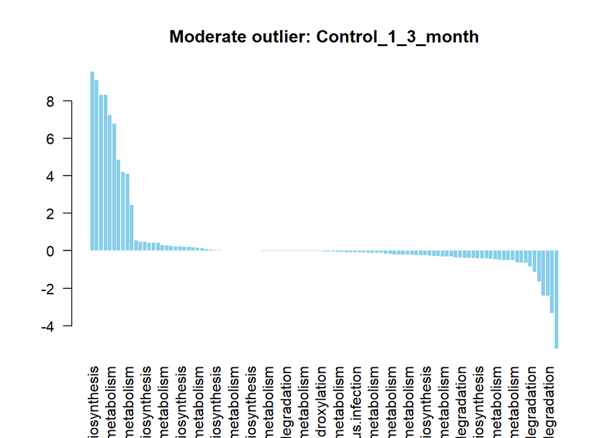

```r
pathways_contrib_T2_99_center  <- outlierContrib(pathways_pca_center, pathways_out_T2_99_center)
```

```
## There are 1 severe outliers in the data provided.
```

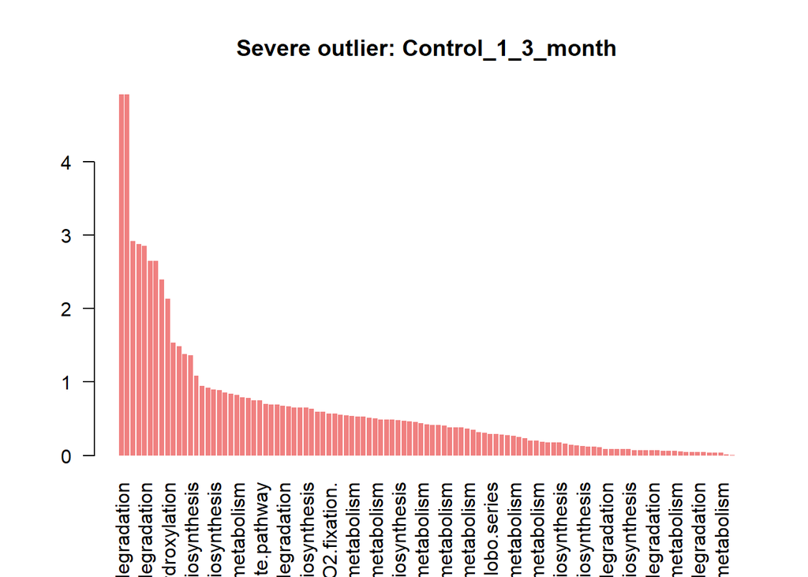

```
## There are no moderate outliers in the data or they were not computed.
```

Definimos una función reutilizable que extrae, para cada muestra anómala, las n variables con mayor contribución en valor absoluto (conservando el signo), y devuelve una lista con una tabla por muestra

```r
get_top_contrib_list <- function(contrib_matrix, n = 10) {
  lapply(rownames(contrib_matrix), function(sample_name) {
    row <- contrib_matrix[sample_name, ]
    top <- row[order(abs(row), decreasing = TRUE)][1:n]
    tibble(
      sample_id    = sample_name,
      pathway      = names(top),
      contribution = as.numeric(top)
    )
  })
}

top10_moderate_center <- get_top_contrib_list(pathways_contrib_RSS_99_center$contribRSS)


top10_moderate_center
```

```
## [[1]]
## # A tibble: 10 × 3
##    sample_id         pathway                                  contribution
##    <chr>             <chr>                                           <dbl>
##  1 Control_1_3_month Pantothenate.and.CoA.biosynthesis                9.56
##  2 Control_1_3_month Cysteine.and.methionine.metabolism               9.13
##  3 Control_1_3_month Pentose.and.glucuronate.interconversions         8.32
##  4 Control_1_3_month Histidine.metabolism                             8.30
##  5 Control_1_3_month Pyrimidine.metabolism                            7.24
##  6 Control_1_3_month Purine.metabolism                                6.78
##  7 Control_1_3_month Ether.lipid.metabolism                          -5.22
##  8 Control_1_3_month Ascorbate.and.aldarate.metabolism                4.86
##  9 Control_1_3_month Porphyrin.and.chlorophyll.metabolism             4.20
## 10 Control_1_3_month beta.Alanine.metabolism                          4.11
```

```r
top10_severe_center   <- get_top_contrib_list(pathways_contrib_T2_99_center$contribT2)

top10_severe_center
```

```
## [[1]]
## # A tibble: 10 × 3
##    sample_id         pathway                                    contribution
##    <chr>             <chr>                                             <dbl>
##  1 Control_1_3_month Biphenyl.degradation                               4.92
##  2 Control_1_3_month Toluene.and.xylene.degradation                     4.92
##  3 Control_1_3_month Penicillin.and.cephalosporin.biosynthesis          2.92
##  4 Control_1_3_month Synthesis.and.degradation.of.ketone.bodies         2.87
##  5 Control_1_3_month Tetrachloroethene.degradation                      2.86
##  6 Control_1_3_month Fluorobenzoate.degradation                         2.64
##  7 Control_1_3_month Styrene.degradation                                2.64
##  8 Control_1_3_month Mannose.type.O.glycan.biosynthesis                 2.39
##  9 Control_1_3_month Benzoate.degradation.via.hydroxylation             2.14
## 10 Control_1_3_month Pentose.and.glucuronate.interconversions           1.54
```

## 5.2 Escalado: standard

### 5.2.1 Cálculo y scree plot

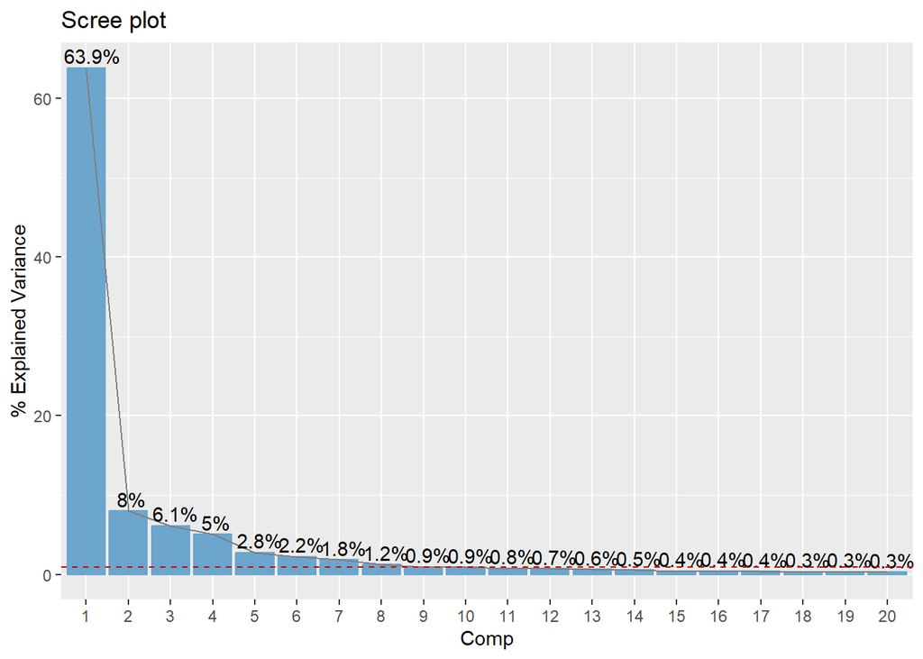

```r
pathways_pca <- pca(
  pathways_X,
  ncomp   = NULL,
  algo    = "nipals",
  scaling = "standard"
)

pcaPlot(pathways_pca, type = "scree")
```

### 5.2.2 Score plots — coloreando por covariables de interés

#### Grupo (caso/control)

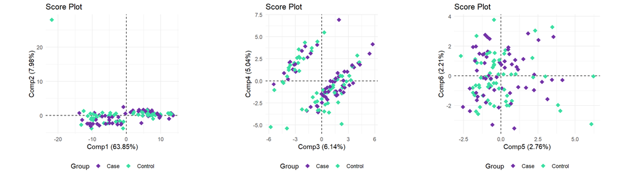

```r
p1 <- pcaPlot(pathways_pca, type = "scores", comp = 1:2,
              colBy = data.frame(Group = pathways_meta$group),
              labels = FALSE, ellipses = FALSE)
p2 <- pcaPlot(pathways_pca, type = "scores", comp = 3:4,
              colBy = data.frame(Group = pathways_meta$group),
              labels = FALSE, ellipses = FALSE)
p3 <- pcaPlot(pathways_pca, type = "scores", comp = 5:6,
              colBy = data.frame(Group = pathways_meta$group),
              labels = FALSE, ellipses = FALSE)

grid.arrange(p1, p2, p3, nrow = 1)
```

#### Tiempo relativo al diagnóstico

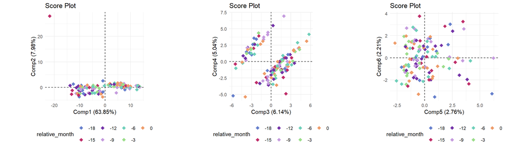

```r
pathways_time <- factor(pathways_meta$relative_month,
                        levels = c(-18, -15, -12, -9, -6, -3, 0))

p1 <- pcaPlot(pathways_pca, type = "scores", comp = 1:2,
              colBy = data.frame(relative_month = pathways_time),
              labels = FALSE, ellipses = FALSE)
p2 <- pcaPlot(pathways_pca, type = "scores", comp = 3:4,
              colBy = data.frame(relative_month = pathways_time),
              labels = FALSE, ellipses = FALSE)
p3 <- pcaPlot(pathways_pca, type = "scores", comp = 5:6,
              colBy = data.frame(relative_month = pathways_time),
              labels = FALSE, ellipses = FALSE)

grid.arrange(p1, p2, p3, nrow = 1)
```

#### País

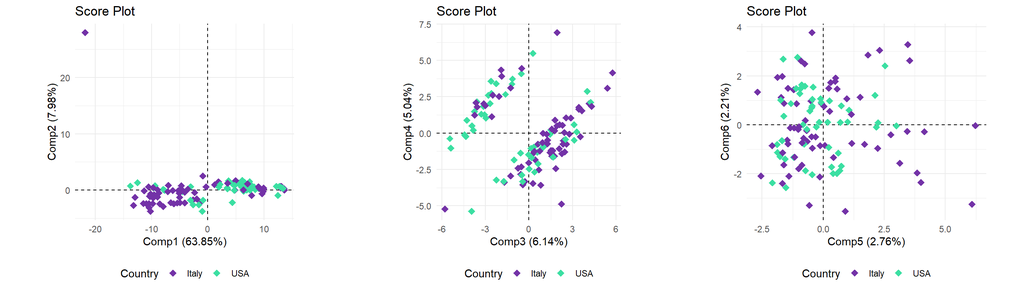

```r
p1 <- pcaPlot(pathways_pca, type = "scores", comp = 1:2,
              colBy = data.frame(Country = pathways_meta$Country),
              labels = FALSE, ellipses = FALSE)
p2 <- pcaPlot(pathways_pca, type = "scores", comp = 3:4,
              colBy = data.frame(Country = pathways_meta$Country),
              labels = FALSE, ellipses = FALSE)
p3 <- pcaPlot(pathways_pca, type = "scores", comp = 5:6,
              colBy = data.frame(Country = pathways_meta$Country),
              labels = FALSE, ellipses = FALSE)

grid.arrange(p1, p2, p3, nrow = 1)
```

#### Sexo

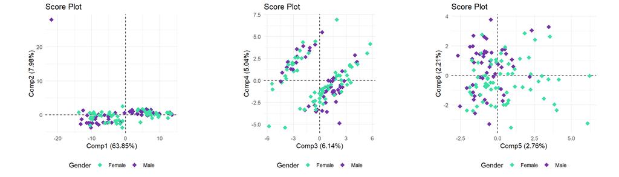

```r
p1 <- pcaPlot(pathways_pca, type = "scores", comp = 1:2,
              colBy = data.frame(Gender = pathways_meta$Gender),
              labels = FALSE, ellipses = FALSE)
p2 <- pcaPlot(pathways_pca, type = "scores", comp = 3:4,
              colBy = data.frame(Gender = pathways_meta$Gender),
              labels = FALSE, ellipses = FALSE)
p3 <- pcaPlot(pathways_pca, type = "scores", comp = 5:6,
              colBy = data.frame(Gender = pathways_meta$Gender),
              labels = FALSE, ellipses = FALSE)

grid.arrange(p1, p2, p3, ncol = 3)
```

#### Tipo de parto

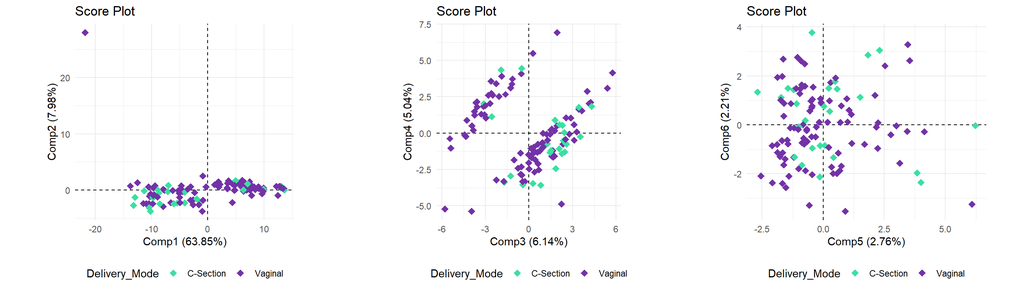

```r
p1 <- pcaPlot(pathways_pca, type = "scores", comp = 1:2,
              colBy = data.frame(Delivery_Mode = pathways_meta$Delivery_Mode),
              labels = FALSE, ellipses = FALSE)
p2 <- pcaPlot(pathways_pca, type = "scores", comp = 3:4,
              colBy = data.frame(Delivery_Mode = pathways_meta$Delivery_Mode),
              labels = FALSE, ellipses = FALSE)
p3 <- pcaPlot(pathways_pca, type = "scores", comp = 5:6,
              colBy = data.frame(Delivery_Mode = pathways_meta$Delivery_Mode),
              labels = FALSE, ellipses = FALSE)

grid.arrange(p1, p2, p3, ncol = 3)
```

#### Riesgo genético (HLA)

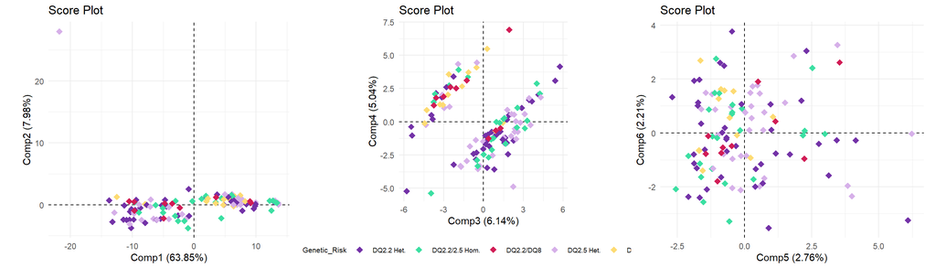

```r
genetic_risk_short <- pathways_meta$Genetic_Risk %>%
  str_replace_all("Homozygous", "Hom.") %>%
  str_replace_all("Heterozygous", "Het.")

p1 <- pcaPlot(pathways_pca, type = "scores", comp = 1:2,
              colBy = data.frame(Genetic_Risk = genetic_risk_short),
              labels = FALSE, ellipses = FALSE) +
  theme(legend.position = "none")

p2 <- pcaPlot(pathways_pca, type = "scores", comp = 3:4,
              colBy = data.frame(Genetic_Risk = genetic_risk_short),
              labels = FALSE, ellipses = FALSE) +
  theme(legend.position = "bottom",
        legend.text  = element_text(size = 7),
        legend.title = element_text(size = 8))

p3 <- pcaPlot(pathways_pca, type = "scores", comp = 5:6,
              colBy = data.frame(Genetic_Risk = genetic_risk_short),
              labels = FALSE, ellipses = FALSE) +
  theme(legend.position = "none")

grid.arrange(p1, p2, p3, ncol = 3)
```

### 5.2.3 Loadings — correlation plots y top variables

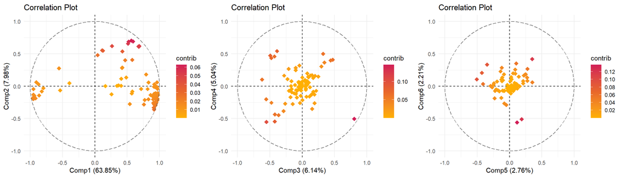

```r
l1 <- pcaPlot(pathways_pca, type = "corr", comp = 1:2,
              colBy = "contrib", shape = "point",
              labels = FALSE, repel = TRUE, col = "hot")
l2 <- pcaPlot(pathways_pca, type = "corr", comp = 3:4,
              colBy = "contrib", shape = "point",
              labels = FALSE, repel = TRUE, col = "hot")
l3 <- pcaPlot(pathways_pca, type = "corr", comp = 5:6,
              colBy = "contrib", shape = "point",
              labels = FALSE, repel = TRUE, col = "hot")

grid.arrange(l1, l2, l3, ncol = 3)
```

**Top 10 pathways — PC1 y PC2**

```r
pathways_top_PC12 <- tibble(
  variable    = rownames(pathways_pca$loadings),
  loading_PC1 = pathways_pca$loadings[, 1],
  loading_PC2 = pathways_pca$loadings[, 2]
) %>%
  mutate(contribution_PC12 = loading_PC1^2 + loading_PC2^2) %>%
  arrange(desc(contribution_PC12)) %>%
  slice_head(n = 10)

kable(pathways_top_PC12)
```

| variable | loading_PC1 | loading_PC2 | contribution_PC12 |
| --- | --- | --- | --- |
| Cysteine.and.methionine.metabolism | 0.0682279 | 0.2416397 | 0.0630448 |
| Pantothenate.and.CoA.biosynthesis | 0.0714445 | 0.2367543 | 0.0611569 |
| Pentose.and.glucuronate.interconversions | 0.0633691 | 0.2356904 | 0.0595656 |
| beta.Alanine.metabolism | 0.0622057 | 0.2249242 | 0.0544604 |
| Porphyrin.and.chlorophyll.metabolism | 0.0832363 | 0.2124591 | 0.0520671 |
| Purine.metabolism | 0.0832238 | 0.2121686 | 0.0519417 |
| Pyrimidine.metabolism | 0.0816570 | 0.2103294 | 0.0509063 |
| Histidine.metabolism | 0.0825699 | 0.2087604 | 0.0503987 |
| Fluorobenzoate.degradation | 0.0321043 | 0.2117328 | 0.0458615 |
| Styrene.degradation | 0.0321043 | 0.2117328 | 0.0458615 |

**Top 10 pathways — PC3 y PC4**

```r
pathways_top_PC34 <- tibble(
  variable    = rownames(pathways_pca$loadings),
  loading_PC3 = pathways_pca$loadings[, 3],
  loading_PC4 = pathways_pca$loadings[, 4]
) %>%
  mutate(contribution_PC34 = loading_PC3^2 + loading_PC4^2) %>%
  arrange(desc(contribution_PC34)) %>%
  slice_head(n = 10)

kable(pathways_top_PC34)
```

| variable | loading_PC3 | loading_PC4 | contribution_PC34 |
| --- | --- | --- | --- |
| Human.papillomavirus.infection | 0.3147571 | -0.2180726 | 0.1466277 |
| Relaxin.signaling.pathway | 0.3147571 | -0.2180726 | 0.1466277 |
| Thermogenesis | 0.3147571 | -0.2180726 | 0.1466277 |
| Lipoic.acid.metabolism | -0.2157308 | -0.2377791 | 0.1030787 |
| Lipopolysaccharide.biosynthesis | -0.1655354 | -0.2347761 | 0.0825218 |
| Synthesis.and.degradation.of.ketone.bodies | -0.1926171 | 0.2037312 | 0.0786078 |
| Glycerophospholipid.metabolism | -0.1518790 | 0.2333978 | 0.0775418 |
| Ascorbate.and.aldarate.metabolism | -0.1862871 | 0.1873661 | 0.0698090 |
| Penicillin.and.cephalosporin.biosynthesis | -0.1672169 | 0.1978306 | 0.0670984 |
| Aflatoxin.biosynthesis | 0.1845753 | 0.1757143 | 0.0649435 |

**Top 10 pathways — PC5 y PC6**

```r
pathways_top_PC56 <- tibble(
  variable    = rownames(pathways_pca$loadings),
  loading_PC5 = pathways_pca$loadings[, 5],
  loading_PC6 = pathways_pca$loadings[, 6]
) %>%
  mutate(contribution_PC56 = loading_PC5^2 + loading_PC6^2) %>%
  arrange(desc(contribution_PC56)) %>%
  slice_head(n = 10)

kable(pathways_top_PC56)
```

| variable | loading_PC5 | loading_PC6 | contribution_PC56 |
| --- | --- | --- | --- |
| Tetrachloroethene.degradation | 0.0683278 | -0.3651729 | 0.1380200 |
| Fluorobenzoate.degradation | 0.1097666 | -0.3326732 | 0.1227201 |
| Styrene.degradation | 0.1097666 | -0.3326732 | 0.1227201 |
| Phenylalanine.metabolism | 0.2042369 | 0.2737372 | 0.1166448 |
| PI3K.Akt.signaling.pathway | -0.2943797 | 0.0682339 | 0.0913153 |
| mTOR.signaling.pathway | -0.2943797 | 0.0682339 | 0.0913153 |
| Glycerolipid.metabolism | -0.2020385 | 0.2169511 | 0.0878874 |
| Aflatoxin.biosynthesis | -0.2488473 | 0.1348886 | 0.0801199 |
| Ether.lipid.metabolism | -0.2381604 | 0.0215667 | 0.0571855 |
| Cysteine.and.methionine.metabolism | 0.1618109 | 0.1726816 | 0.0560017 |

Fijamos el número de componentes antes de estudiar los anómalos para evitar problemas con los gráficos.

```r
pathways_pca <- pca(
  pathways_X,
  ncomp   = 4,
  algo    = "nipals",
  scaling = "standard"
)
```

### 5.2.4 Detección de muestras anómalas

```r
par(mfrow = c(1, 2))

pathways_out_RSS <- pcaOutliers(pathways_pca, ncomp = pathways_pca$ncomp,
                               method = "RSS", conf = 0.95)
pathways_out_T2  <- pcaOutliers(pathways_pca, ncomp = pathways_pca$ncomp,
                               method = "T2",  conf = 0.95)
```

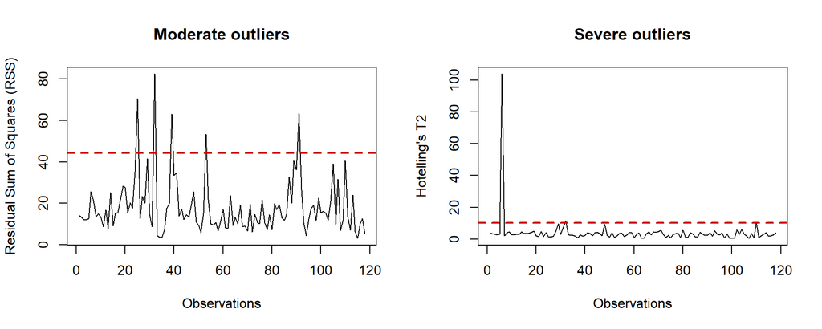

```r
par(mfrow = c(1, 1))
```

```r
pathways_moderate <- sort(
  pathways_out_RSS$RSS[pathways_out_RSS$ModerateOutliers],
  decreasing = TRUE
)

pathways_severe <- sort(
  pathways_out_T2$T2[pathways_out_T2$SevereOutliers],
  decreasing = TRUE
)

cat("Anómalos moderados (RSS) al 95 :\n"); print(pathways_moderate)
```

```
## Anómalos moderados (RSS) al 95 :
```

```
## Control_3_4-6_month    Case_3_4-6_month   Control_8_9_month    Case_4_4-6_month
##            82.51969            70.47578            63.39696            63.17367
##  Control_5_33_month
##            53.46837
```

```r
cat("\nAnómalos severos (T²) al 95 :\n");   print(pathways_severe)
```

```
##
## Anómalos severos (T²) al 95 :
```

```
##   Control_1_3_month Control_3_4-6_month     Case_10_9_month
##           103.90316            11.17022            10.69123
```

```r
par(mfrow = c(1, 2))

pathways_out_RSS_99 <- pcaOutliers(pathways_pca, ncomp = pathways_pca$ncomp,method = "RSS", conf = 0.99)

pathways_out_T2_99  <- pcaOutliers(pathways_pca, ncomp = pathways_pca$ncomp,method = "T2",  conf = 0.99)
```

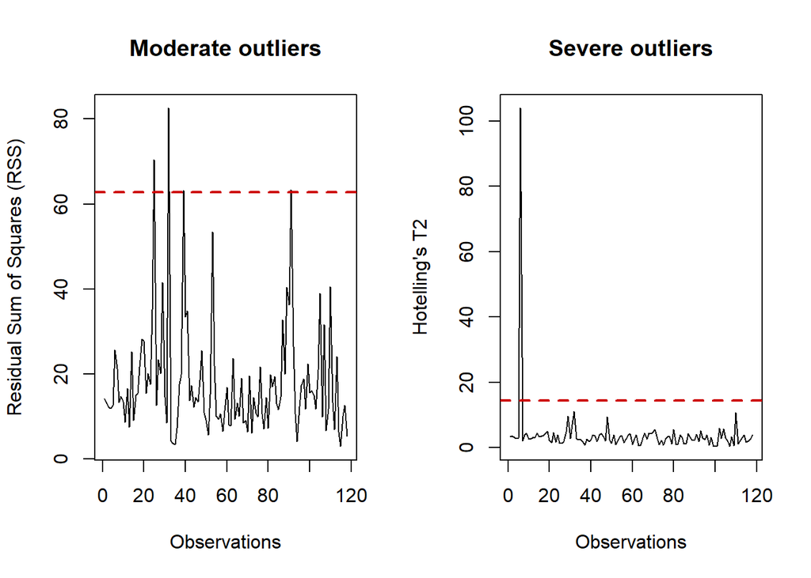

```r
par(mfrow = c(1, 1))
```

```r
pathways_moderate_99 <- sort(pathways_out_RSS_99$RSS[pathways_out_RSS_99$ModerateOutliers],
                    decreasing = TRUE)
pathways_severe_99   <- sort(pathways_out_T2_99$T2[pathways_out_T2_99$SevereOutliers],
                    decreasing = TRUE)

cat("Moderados (RSS) al 99 :\n"); print(pathways_moderate_99)
```

```
## Moderados (RSS) al 99 :
```

```
## Control_3_4-6_month    Case_3_4-6_month   Control_8_9_month    Case_4_4-6_month
##            82.51969            70.47578            63.39696            63.17367
```

```r
cat("Severos   (T²) al 99 :\n");  print(pathways_severe_99)
```

```
## Severos   (T²) al 99 :
```

```
## Control_1_3_month
##          103.9032
```

```r
pathways_contrib_RSS_99 <- outlierContrib(pathways_pca, pathways_out_RSS_99)
```

```
## There are no severe outliers in the data or they were not computed.
```

```
## There are 4 moderate outliers in the data provided.
```

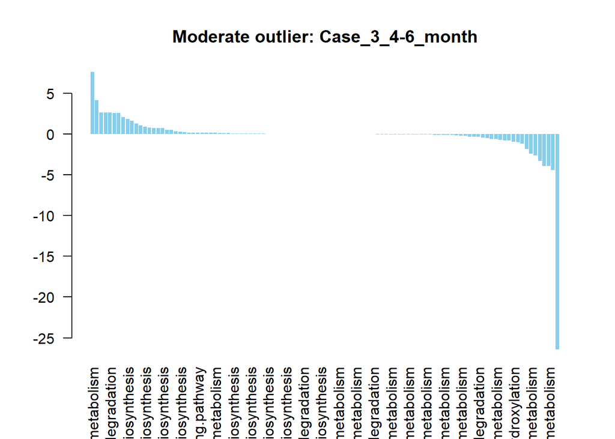

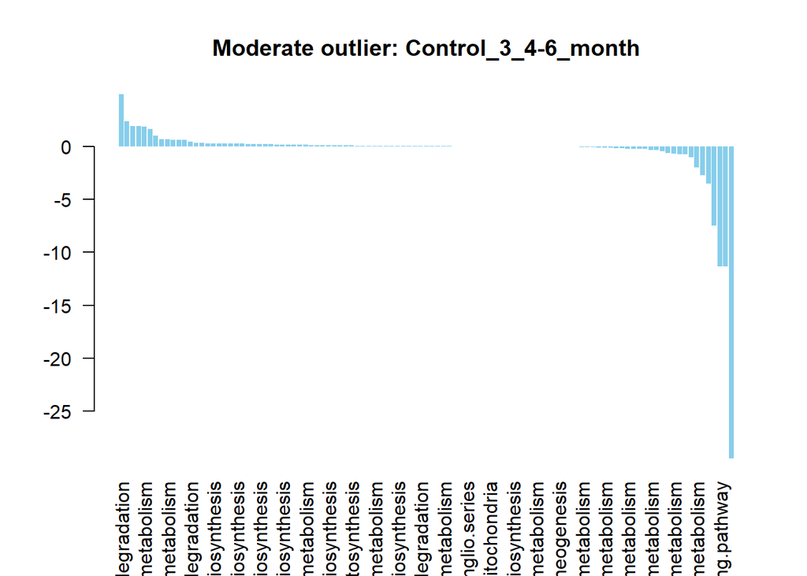

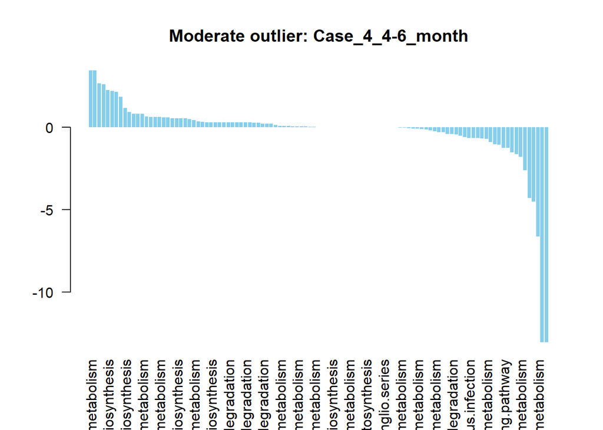

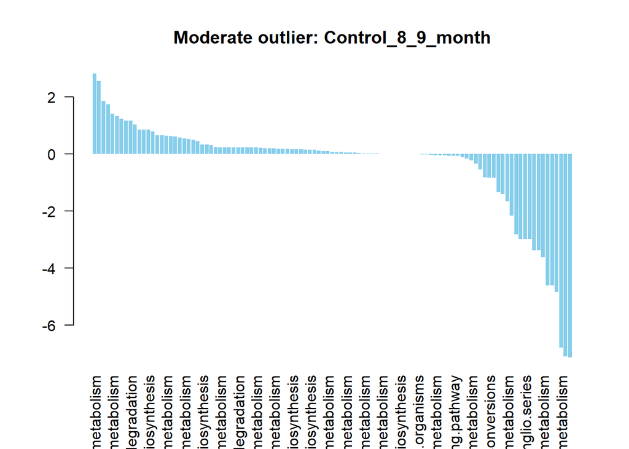

```r
pathways_contrib_T2_99  <- outlierContrib(pathways_pca, pathways_out_T2_99)
```

```
## There are 1 severe outliers in the data provided.
```

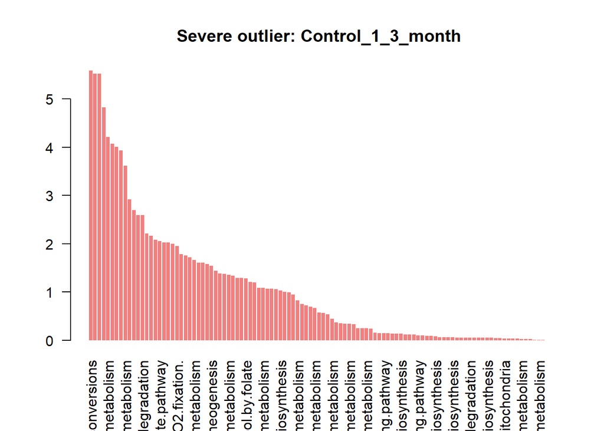

```
## There are no moderate outliers in the data or they were not computed.
```

Definimos una función reutilizable que extrae, para cada muestra anómala, las n variables con mayor contribución en valor absoluto (conservando el signo), y devuelve una lista con una tabla por muestra

```r
get_top_contrib_list <- function(contrib_matrix, n = 10) {
  lapply(rownames(contrib_matrix), function(sample_name) {
    row <- contrib_matrix[sample_name, ]
    top <- row[order(abs(row), decreasing = TRUE)][1:n]
    tibble(
      sample_id    = sample_name,
      pathway      = names(top),
      contribution = as.numeric(top)
    )
  })
}

top10_moderate <- get_top_contrib_list(pathways_contrib_RSS_99$contribRSS)


top10_moderate
```

```
## [[1]]
## # A tibble: 10 × 3
##    sample_id        pathway                       contribution
##    <chr>            <chr>                                <dbl>
##  1 Case_3_4-6_month Sulfur.metabolism                   -26.4
##  2 Case_3_4-6_month Butanoate.metabolism                  7.64
##  3 Case_3_4-6_month Citrate.cycle..TCA.cycle.            -4.42
##  4 Case_3_4-6_month Glutathione.metabolism                4.13
##  5 Case_3_4-6_month Starch.and.sucrose.metabolism        -3.93
##  6 Case_3_4-6_month Vitamin.B6.metabolism                -3.92
##  7 Case_3_4-6_month Atrazine.degradation                 -3.32
##  8 Case_3_4-6_month Tyrosine.metabolism                   2.67
##  9 Case_3_4-6_month Fluorobenzoate.degradation            2.65
## 10 Case_3_4-6_month Styrene.degradation                   2.65
##
## [[2]]
## # A tibble: 10 × 3
##    sample_id           pathway                                 contribution
##    <chr>               <chr>                                          <dbl>
##  1 Control_3_4-6_month Glycerolipid.metabolism                       -29.4
##  2 Control_3_4-6_month PI3K.Akt.signaling.pathway                    -11.3
##  3 Control_3_4-6_month mTOR.signaling.pathway                        -11.3
##  4 Control_3_4-6_month Aflatoxin.biosynthesis                         -7.51
##  5 Control_3_4-6_month Atrazine.degradation                            4.92
##  6 Control_3_4-6_month Lipoic.acid.metabolism                         -3.53
##  7 Control_3_4-6_month Lipopolysaccharide.biosynthesis                -2.74
##  8 Control_3_4-6_month Tetrachloroethene.degradation                   2.35
##  9 Control_3_4-6_month Glyoxylate.and.dicarboxylate.metabolism        -2.01
## 10 Control_3_4-6_month Fluorobenzoate.degradation                      1.94
##
## [[3]]
## # A tibble: 10 × 3
##    sample_id        pathway                              contribution
##    <chr>            <chr>                                       <dbl>
##  1 Case_4_4-6_month Biphenyl.degradation                       -13.1
##  2 Case_4_4-6_month Toluene.and.xylene.degradation             -13.1
##  3 Case_4_4-6_month Sphingolipid.metabolism                     -6.63
##  4 Case_4_4-6_month Citrate.cycle..TCA.cycle.                   -4.50
##  5 Case_4_4-6_month Butanoate.metabolism                        -4.30
##  6 Case_4_4-6_month Glutathione.metabolism                       3.47
##  7 Case_4_4-6_month Porphyrin.and.chlorophyll.metabolism         3.46
##  8 Case_4_4-6_month beta.Alanine.metabolism                      2.68
##  9 Case_4_4-6_month Atrazine.degradation                         2.62
## 10 Case_4_4-6_month Vitamin.B6.metabolism                       -2.60
##
## [[4]]
## # A tibble: 10 × 3
##    sample_id         pathway                                       contribution
##    <chr>             <chr>                                                <dbl>
##  1 Control_8_9_month Fatty.acid.biosynthesis                              -7.13
##  2 Control_8_9_month Nitrogen.metabolism                                  -7.11
##  3 Control_8_9_month Cyanoamino.acid.metabolism                           -6.79
##  4 Control_8_9_month Aflatoxin.biosynthesis                               -4.84
##  5 Control_8_9_month PI3K.Akt.signaling.pathway                           -4.62
##  6 Control_8_9_month mTOR.signaling.pathway                               -4.62
##  7 Control_8_9_month Butanoate.metabolism                                 -3.63
##  8 Control_8_9_month Glycosphingolipid.biosynthesis...globo.series        -3.38
##  9 Control_8_9_month High.mannose.type.N.glycan.biosynthesis              -3.38
## 10 Control_8_9_month Glycosaminoglycan.degradation                        -2.98
```

```r
top10_severe   <- get_top_contrib_list(pathways_contrib_T2_99$contribT2)

top10_severe
```

```
## [[1]]
## # A tibble: 10 × 3
##    sample_id         pathway                                  contribution
##    <chr>             <chr>                                           <dbl>
##  1 Control_1_3_month Pentose.and.glucuronate.interconversions         5.59
##  2 Control_1_3_month Cysteine.and.methionine.metabolism               5.52
##  3 Control_1_3_month Pantothenate.and.CoA.biosynthesis                5.52
##  4 Control_1_3_month beta.Alanine.metabolism                          4.83
##  5 Control_1_3_month Purine.metabolism                                4.21
##  6 Control_1_3_month Pyrimidine.metabolism                            4.07
##  7 Control_1_3_month Histidine.metabolism                             4.01
##  8 Control_1_3_month Porphyrin.and.chlorophyll.metabolism             3.93
##  9 Control_1_3_month Phenylalanine.metabolism                         3.62
## 10 Control_1_3_month Aminoacyl.tRNA.biosynthesis                      2.92
```

# 6. PCA — Metabolites

## 6.1 Escalado: center

### 6.1.1 Cálculo y scree plot

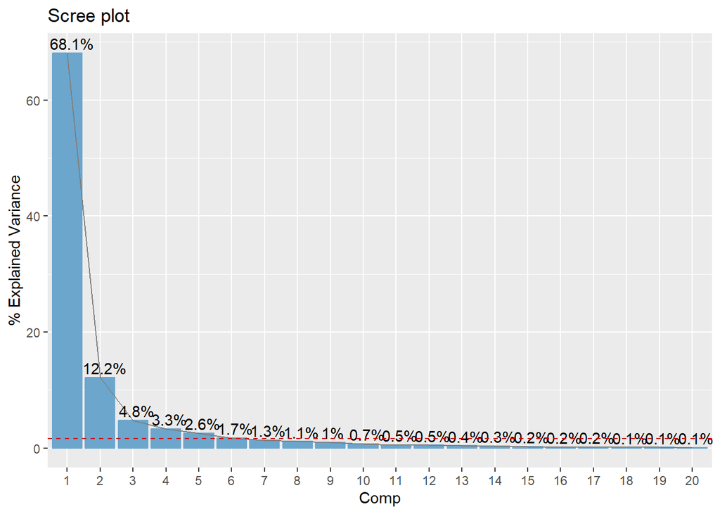

```r
metabolites_pca_center <- pca(
  metabolites_X,
  ncomp   = NULL,
  algo    = "nipals",
  scaling = "center"
)

pcaPlot(metabolites_pca_center, type = "scree")
```

### 6.1.2 Score plots — coloreando por covariables de interés

#### Grupo (caso/control)

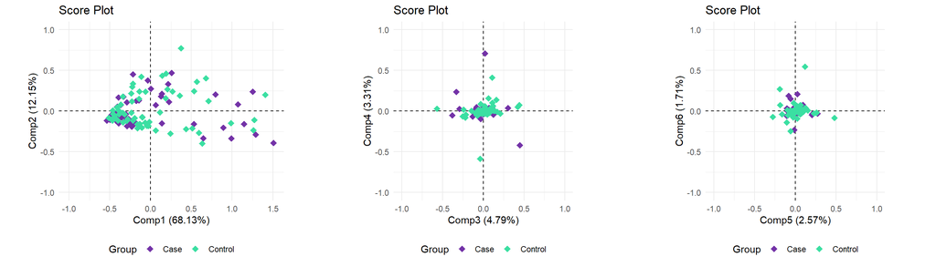

```r
p1 <- pcaPlot(metabolites_pca_center, type = "scores", comp = 1:2,
              colBy = data.frame(Group = metabolites_meta$group),
              labels = FALSE, ellipses = FALSE)
p2 <- pcaPlot(metabolites_pca_center, type = "scores", comp = 3:4,
              colBy = data.frame(Group = metabolites_meta$group),
              labels = FALSE, ellipses = FALSE)
p3 <- pcaPlot(metabolites_pca_center, type = "scores", comp = 5:6,
              colBy = data.frame(Group = metabolites_meta$group),
              labels = FALSE, ellipses = FALSE)

grid.arrange(p1, p2, p3, nrow = 1)
```

#### Tiempo relativo al diagnóstico

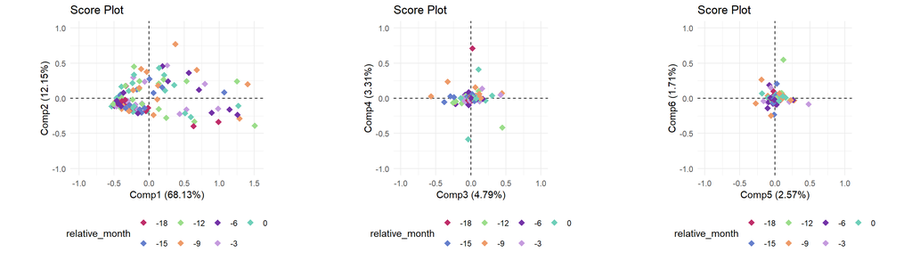

```r
metabolites_time <- factor(metabolites_meta$relative_month,
                           levels = c(-18, -15, -12, -9, -6, -3, 0))

p1 <- pcaPlot(metabolites_pca_center, type = "scores", comp = 1:2,
              colBy = data.frame(relative_month = metabolites_time),
              labels = FALSE, ellipses = FALSE)
p2 <- pcaPlot(metabolites_pca_center, type = "scores", comp = 3:4,
              colBy = data.frame(relative_month = metabolites_time),
              labels = FALSE, ellipses = FALSE)
p3 <- pcaPlot(metabolites_pca_center, type = "scores", comp = 5:6,
              colBy = data.frame(relative_month = metabolites_time),
              labels = FALSE, ellipses = FALSE)

grid.arrange(p1, p2, p3, nrow = 1)
```

#### País

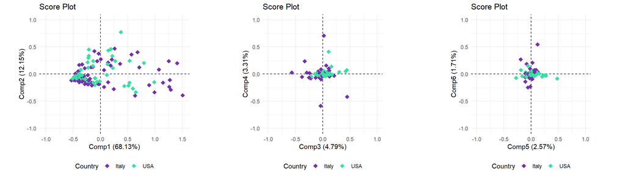

```r
p1 <- pcaPlot(metabolites_pca_center, type = "scores", comp = 1:2,
              colBy = data.frame(Country = metabolites_meta$Country),
              labels = FALSE, ellipses = FALSE)
p2 <- pcaPlot(metabolites_pca_center, type = "scores", comp = 3:4,
              colBy = data.frame(Country = metabolites_meta$Country),
              labels = FALSE, ellipses = FALSE)
p3 <- pcaPlot(metabolites_pca_center, type = "scores", comp = 5:6,
              colBy = data.frame(Country = metabolites_meta$Country),
              labels = FALSE, ellipses = FALSE)

grid.arrange(p1, p2, p3, nrow = 1)
```

#### Sexo

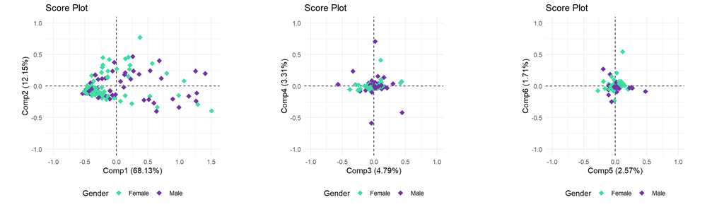

```r
p1 <- pcaPlot(metabolites_pca_center, type = "scores", comp = 1:2,
              colBy = data.frame(Gender = metabolites_meta$Gender),
              labels = FALSE, ellipses = FALSE)
p2 <- pcaPlot(metabolites_pca_center, type = "scores", comp = 3:4,
              colBy = data.frame(Gender = metabolites_meta$Gender),
              labels = FALSE, ellipses = FALSE)
p3 <- pcaPlot(metabolites_pca_center, type = "scores", comp = 5:6,
              colBy = data.frame(Gender = metabolites_meta$Gender),
              labels = FALSE, ellipses = FALSE)

grid.arrange(p1, p2, p3, ncol = 3)
```

#### Tipo de parto

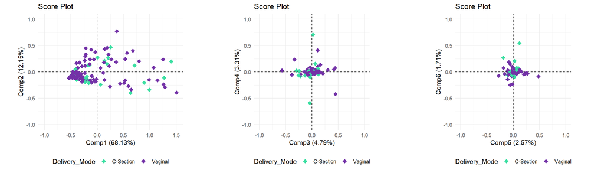

```r
p1 <- pcaPlot(metabolites_pca_center, type = "scores", comp = 1:2,
              colBy = data.frame(Delivery_Mode = metabolites_meta$Delivery_Mode),
              labels = FALSE, ellipses = FALSE)
p2 <- pcaPlot(metabolites_pca_center, type = "scores", comp = 3:4,
              colBy = data.frame(Delivery_Mode = metabolites_meta$Delivery_Mode),
              labels = FALSE, ellipses = FALSE)
p3 <- pcaPlot(metabolites_pca_center, type = "scores", comp = 5:6,
              colBy = data.frame(Delivery_Mode = metabolites_meta$Delivery_Mode),
              labels = FALSE, ellipses = FALSE)

grid.arrange(p1, p2, p3, ncol = 3)
```

#### Riesgo genético (HLA)

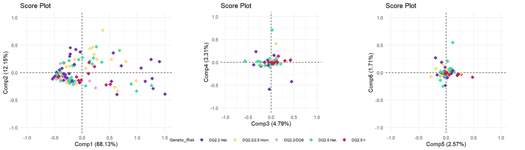

```r
genetic_risk_short <- metabolites_meta$Genetic_Risk %>%
  str_replace_all("Homozygous", "Hom.") %>%
  str_replace_all("Heterozygous", "Het.")

p1 <- pcaPlot(metabolites_pca_center, type = "scores", comp = 1:2,
              colBy = data.frame(Genetic_Risk = genetic_risk_short),
              labels = FALSE, ellipses = FALSE) +
  theme(legend.position = "none")

p2 <- pcaPlot(metabolites_pca_center, type = "scores", comp = 3:4,
              colBy = data.frame(Genetic_Risk = genetic_risk_short),
              labels = FALSE, ellipses = FALSE) +
  theme(legend.position = "bottom",
        legend.text  = element_text(size = 7),
        legend.title = element_text(size = 8))

p3 <- pcaPlot(metabolites_pca_center, type = "scores", comp = 5:6,
              colBy = data.frame(Genetic_Risk = genetic_risk_short),
              labels = FALSE, ellipses = FALSE) +
  theme(legend.position = "none")

grid.arrange(p1, p2, p3, ncol = 3)
```

### 6.1.3 Loadings — correlation plots y top variables

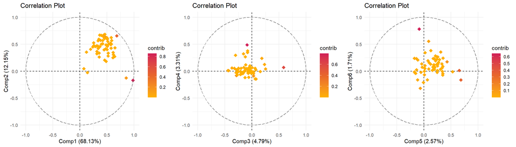

```r
l1 <- pcaPlot(metabolites_pca_center, type = "corr", comp = 1:2,
              colBy = "contrib", shape = "point",
              labels = FALSE, repel = TRUE, col = "hot")
l2 <- pcaPlot(metabolites_pca_center, type = "corr", comp = 3:4,
              colBy = "contrib", shape = "point",
              labels = FALSE, repel = TRUE, col = "hot")
l3 <- pcaPlot(metabolites_pca_center, type = "corr", comp = 5:6,
              colBy = "contrib", shape = "point",
              labels = FALSE, repel = TRUE, col = "hot")

grid.arrange(l1, l2, l3, ncol = 3)
```

**Top 10 metabolitos — PC1 y PC2**

```r
metabolites_top_PC12_center <- tibble(
  variable    = rownames(metabolites_pca_center$loadings),
  loading_PC1 = metabolites_pca_center$loadings[, 1],
  loading_PC2 = metabolites_pca_center$loadings[, 2]
) %>%
  mutate(contribution_PC12 = loading_PC1^2 + loading_PC2^2) %>%
  arrange(desc(contribution_PC12)) %>%
  slice_head(n = 10)

kable(metabolites_top_PC12_center)
```

| variable | loading_PC1 | loading_PC2 | contribution_PC12 |
| --- | --- | --- | --- |
| Glucose | 0.8592955 | -0.3497952 | 0.8607455 |
| Cyclohexanecarboxylic.acid | 0.2683391 | 0.6093181 | 0.4432744 |
| Glycerol | 0.1651387 | 0.5048769 | 0.2821715 |
| Allose | 0.3416673 | -0.1194123 | 0.1309959 |
| Decanoic.acid | 0.0645144 | 0.2247145 | 0.0546587 |
| Serine | 0.0759231 | 0.1546607 | 0.0296842 |
| Ribose | 0.0551552 | 0.1516173 | 0.0260299 |
| Propanal | 0.0574178 | 0.1205041 | 0.0178180 |
| N.Acetyl.D.galactosamine | 0.0745819 | 0.0794121 | 0.0118687 |
| Tagatose | 0.0728329 | 0.0708510 | 0.0103245 |

**Top 10 metabolitos — PC3 y PC4**

```r
metabolites_top_PC34_center <- tibble(
  variable    = rownames(metabolites_pca_center$loadings),
  loading_PC3 = metabolites_pca_center$loadings[, 3],
  loading_PC4 = metabolites_pca_center$loadings[, 4]
) %>%
  mutate(contribution_PC34 = loading_PC3^2 + loading_PC4^2) %>%
  arrange(desc(contribution_PC34)) %>%
  slice_head(n = 10)

kable(metabolites_top_PC34_center)
```

| variable | loading_PC3 | loading_PC4 | contribution_PC34 |
| --- | --- | --- | --- |
| Allose | -0.1344489 | 0.8840805 | 0.7996749 |
| Glycerol | 0.7557071 | 0.1093018 | 0.5830401 |
| Cyclohexanecarboxylic.acid | -0.4234019 | -0.1441738 | 0.2000553 |
| Glucose | 0.0986779 | -0.3470091 | 0.1301527 |
| Propanal | -0.2148521 | 0.0070884 | 0.0462117 |
| Glycine | 0.1098061 | 0.1719337 | 0.0416186 |
| Serine | -0.1846751 | 0.0361768 | 0.0354137 |
| Ribose | 0.1669973 | 0.0332901 | 0.0289963 |
| Decanoic.acid | -0.1562523 | 0.0163129 | 0.0246809 |
| Glycolic.acid | 0.1316325 | 0.0840547 | 0.0243923 |

**Top 10 metabolitos — PC5 y PC6**

```r
metabolites_top_PC56_center <- tibble(
  variable    = rownames(metabolites_pca_center$loadings),
  loading_PC5 = metabolites_pca_center$loadings[, 5],
  loading_PC6 = metabolites_pca_center$loadings[, 6]
) %>%
  mutate(contribution_PC56 = loading_PC5^2 + loading_PC6^2) %>%
  arrange(desc(contribution_PC56)) %>%
  slice_head(n = 10)

kable(metabolites_top_PC56_center)
```

| variable | loading_PC5 | loading_PC6 | contribution_PC56 |
| --- | --- | --- | --- |
| N.Acetyl.D.galactosamine | -0.0732295 | 0.8018363 | 0.6483041 |
| Ribose | 0.5902856 | 0.0147943 | 0.3486560 |
| Glycine | 0.5620887 | -0.1654861 | 0.3433294 |
| Glycolic.acid | 0.3319798 | 0.1656076 | 0.1376365 |
| Glycerol | -0.2858273 | -0.0691561 | 0.0864798 |
| Propanal | -0.0447631 | -0.2570123 | 0.0680591 |
| X1.Deoxypentitol | 0.0293864 | 0.2282636 | 0.0529678 |
| Decanoic.acid | 0.1400945 | 0.1006758 | 0.0297621 |
| Galactose | 0.0990277 | 0.1384028 | 0.0289618 |
| Cyclohexanecarboxylic.acid | 0.0199347 | -0.1647288 | 0.0275330 |

Fijamos el número de componentes antes de estudiar los anómalos para evitar problemas con los gráficos.

```r
metabolites_pca_center <- pca(
  metabolites_X,
  ncomp   = 4,
  algo    = "nipals",
  scaling = "center"
)
```

### 6.1.4 Detección de muestras anómalas

```r
par(mfrow = c(1, 2))

metabolites_out_RSS_center <- pcaOutliers(metabolites_pca_center, ncomp = metabolites_pca_center$ncomp,method = "RSS", conf = 0.95)

metabolites_out_T2_center  <- pcaOutliers(metabolites_pca_center, ncomp = metabolites_pca_center$ncomp,method = "T2",  conf = 0.95)
```

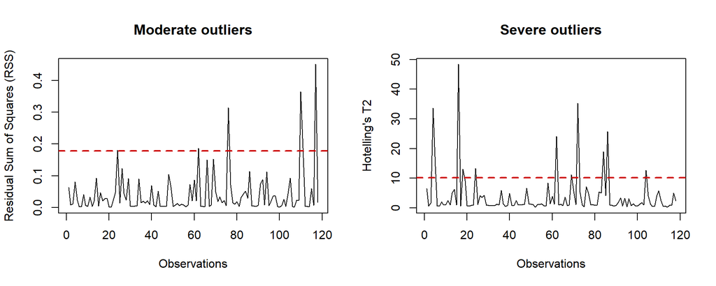

```r
par(mfrow = c(1, 1))
```

```r
metabolites_moderate_center <- sort(
  metabolites_out_RSS_center$RSS[metabolites_out_RSS_center$ModerateOutliers],
  decreasing = TRUE
)

metabolites_severe_center <- sort(
  metabolites_out_T2_center$T2[metabolites_out_T2_center$SevereOutliers],
  decreasing = TRUE
)

cat("Anómalos moderados (RSS) al 95 :\n"); print(metabolites_moderate_center)
```

```
## Anómalos moderados (RSS) al 95 :
```

```
## Control_9_27_month  Control_8_6_month Control_3_15_month  Control_8_9_month
##          0.4508161          0.3645483          0.3139718          0.1877939
##  Control_1_9_month     Case_3_9_month
##          0.1868633          0.1810791
```

```r
cat("\nAnómalos severos (T²) al 95 :\n");   print(metabolites_severe_center)
```

```
##
## Anómalos severos (T²) al 95 :
```

```
##     Case_2_6_month Control_2_24_month     Case_1_6_month  Control_4_9_month
##           48.41374           35.25950           33.64453           25.71745
##  Control_1_9_month Control_4_18_month     Case_1_9_month     Case_3_9_month
##           24.12935           18.97795           14.06322           13.34055
##    Case_3_12_month Control_7_27_month Control_2_15_month
##           13.00604           12.63434           11.14968
```

```r
par(mfrow = c(1, 2))

metabolites_out_RSS_99_center <- pcaOutliers(metabolites_pca_center, ncomp = metabolites_pca_center$ncomp,method = "RSS", conf = 0.99)

metabolites_out_T2_99_center  <- pcaOutliers(metabolites_pca_center, ncomp = metabolites_pca_center$ncomp,method = "T2",  conf = 0.99)
```

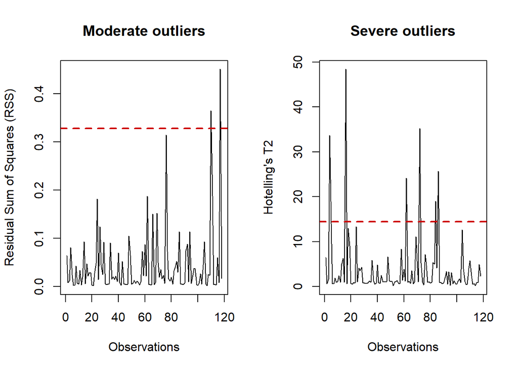

```r
par(mfrow = c(1, 1))
```

```r
metabolites_moderate_99_center <- sort(metabolites_out_RSS_99_center$RSS[metabolites_out_RSS_99_center$ModerateOutliers],
                    decreasing = TRUE)
metabolites_severe_99_center   <- sort(metabolites_out_T2_99_center$T2[metabolites_out_T2_99_center$SevereOutliers],
                    decreasing = TRUE)

cat("Moderados (RSS) al 99 :\n"); print(metabolites_moderate_99_center)
```

```
## Moderados (RSS) al 99 :
```

```
## Control_9_27_month  Control_8_6_month
##          0.4508161          0.3645483
```

```r
cat("Severos   (T²) al 99 :\n");  print(metabolites_severe_99_center)
```

```
## Severos   (T²) al 99 :
```

```
##     Case_2_6_month Control_2_24_month     Case_1_6_month  Control_4_9_month
##           48.41374           35.25950           33.64453           25.71745
##  Control_1_9_month Control_4_18_month
##           24.12935           18.97795
```

```r
metabolites_contrib_T2_99_center <- outlierContrib(metabolites_pca_center, metabolites_out_T2_99_center)
```

```
## There are 6 severe outliers in the data provided.
```

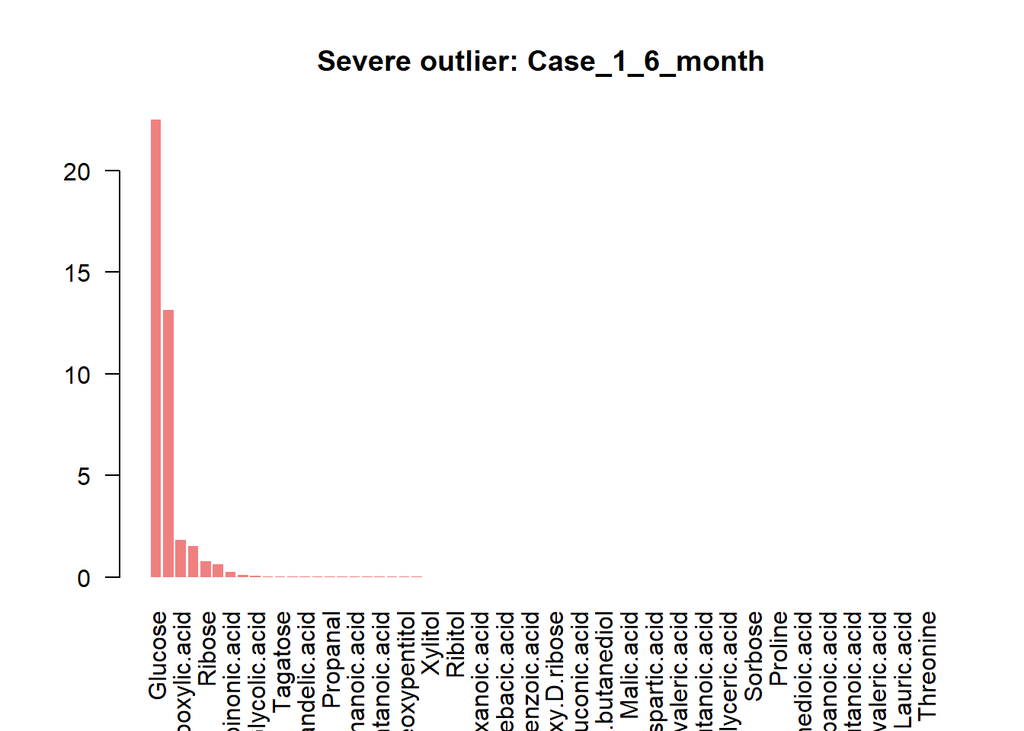

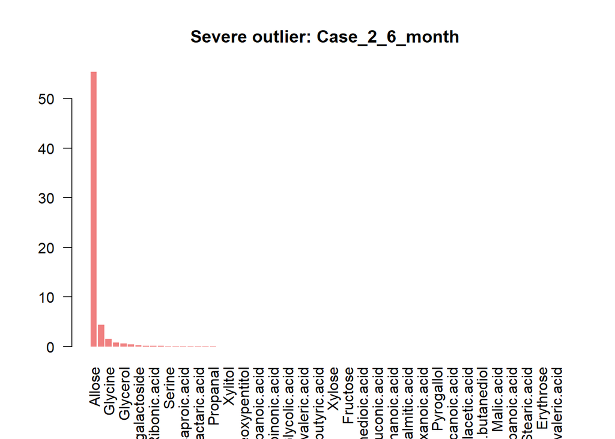

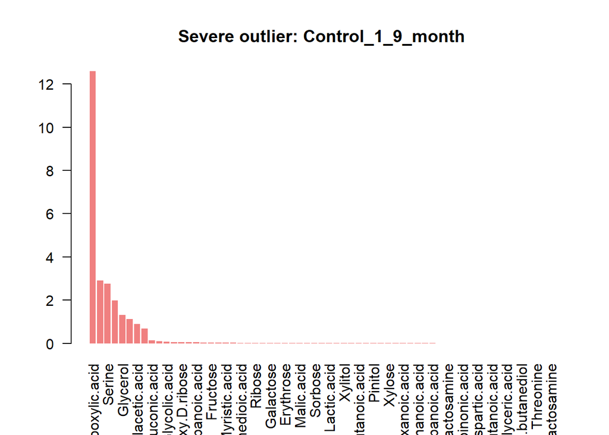

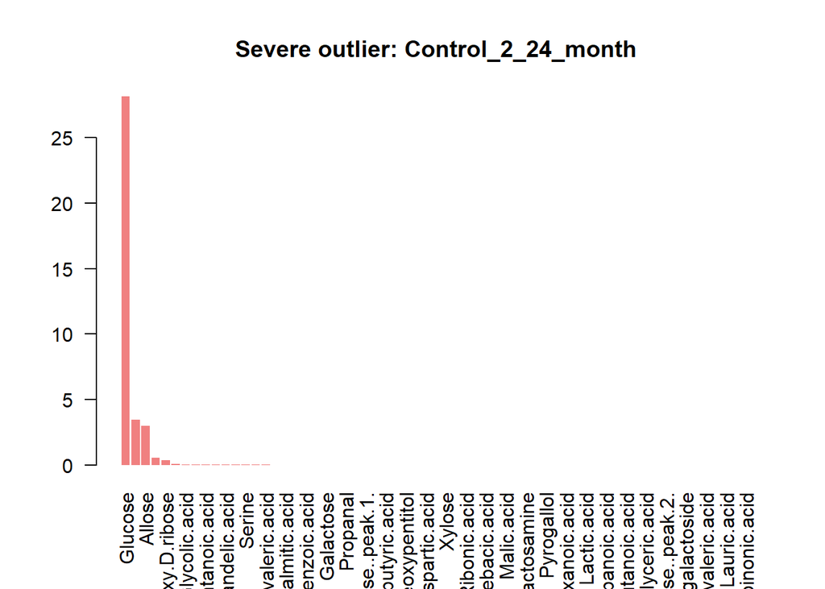

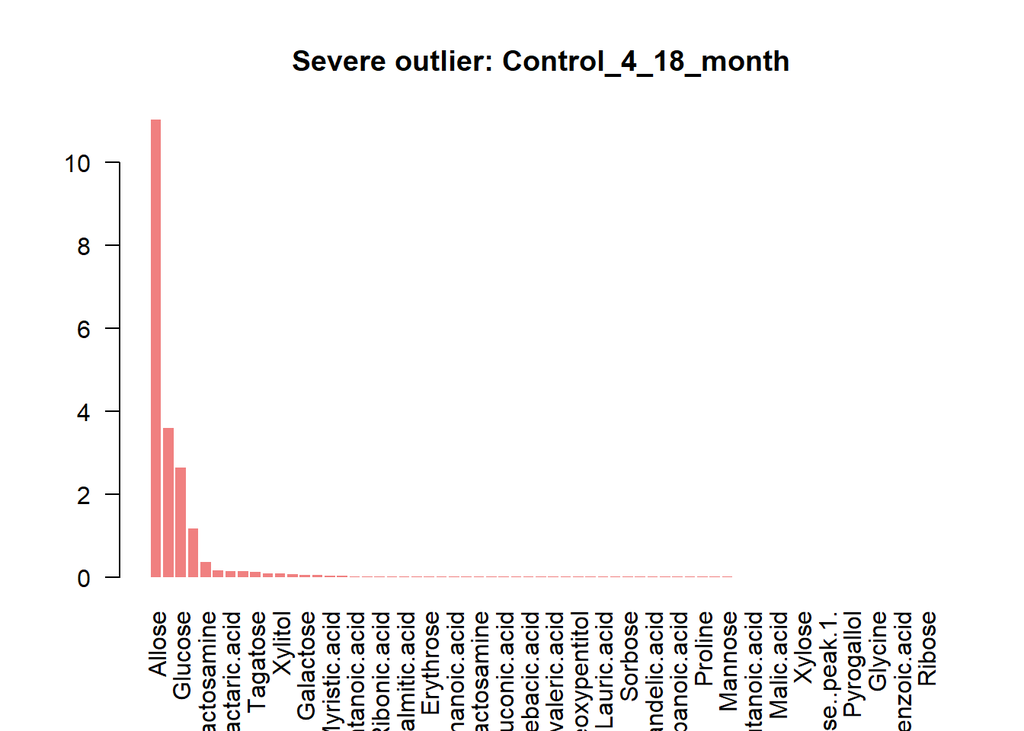

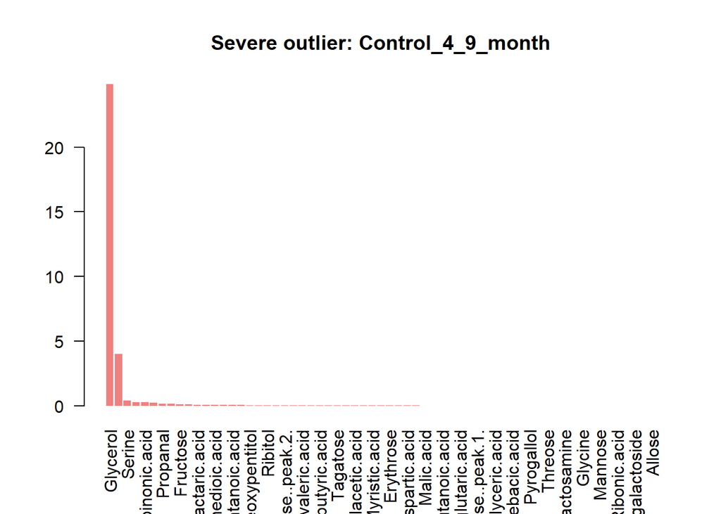

```
## There are no moderate outliers in the data or they were not computed.
```

```r
top10_severe_metabolites_center <- get_top_contrib_list(metabolites_contrib_T2_99_center$contribT2)

top10_severe_metabolites_center
```

```
## [[1]]
## # A tibble: 10 × 3
##    sample_id      pathway                    contribution
##    <chr>          <chr>                             <dbl>
##  1 Case_1_6_month Glucose                         22.5
##  2 Case_1_6_month Glycerol                        13.1
##  3 Case_1_6_month Cyclohexanecarboxylic.acid       1.83
##  4 Case_1_6_month Allose                           1.53
##  5 Case_1_6_month Ribose                           0.760
##  6 Case_1_6_month xi.2.Ethyl.1.hexanol             0.614
##  7 Case_1_6_month Arabinonic.acid                  0.241
##  8 Case_1_6_month Glycine                          0.106
##  9 Case_1_6_month Glycolic.acid                    0.0765
## 10 Case_1_6_month X2.Hydroxyisocaproic.acid        0.0407
##
## [[2]]
## # A tibble: 10 × 3
##    sample_id      pathway                    contribution
##    <chr>          <chr>                             <dbl>
##  1 Case_2_6_month Allose                           55.4
##  2 Case_2_6_month Glucose                           4.41
##  3 Case_2_6_month Glycine                           1.52
##  4 Case_2_6_month Myristic.acid                     0.798
##  5 Case_2_6_month Glycerol                          0.584
##  6 Case_2_6_month Cyclohexanecarboxylic.acid        0.428
##  7 Case_2_6_month Methyl.galactoside                0.209
##  8 Case_2_6_month Arabinose..peak.2.                0.147
##  9 Case_2_6_month Ribonic.acid                      0.130
## 10 Case_2_6_month Ribose                            0.119
##
## [[3]]
## # A tibble: 10 × 3
##    sample_id         pathway                     contribution
##    <chr>             <chr>                              <dbl>
##  1 Control_1_9_month Cyclohexanecarboxylic.acid       12.6
##  2 Control_1_9_month Propanal                          2.92
##  3 Control_1_9_month Serine                            2.76
##  4 Control_1_9_month Tagatose                          1.97
##  5 Control_1_9_month Glycerol                          1.31
##  6 Control_1_9_month Allose                            1.13
```

[output cut: 34 more lines]

```
##
## [[6]]
## # A tibble: 10 × 3
##    sample_id         pathway                    contribution
##    <chr>             <chr>                             <dbl>
##  1 Control_4_9_month Glycerol                         24.9
##  2 Control_4_9_month Cyclohexanecarboxylic.acid        4.00
##  3 Control_4_9_month Serine                            0.401
##  4 Control_4_9_month xi.2.Ethyl.1.hexanol              0.271
##  5 Control_4_9_month Arabinonic.acid                   0.269
##  6 Control_4_9_month Decanoic.acid                     0.222
##  7 Control_4_9_month Propanal                          0.169
##  8 Control_4_9_month Glucose                           0.164
##  9 Control_4_9_month Fructose                          0.119
## 10 Control_4_9_month X2.Deoxy.D.ribose                 0.107
```

## 6.2 Escalado: standard

### 6.2.1 Cálculo y scree plot

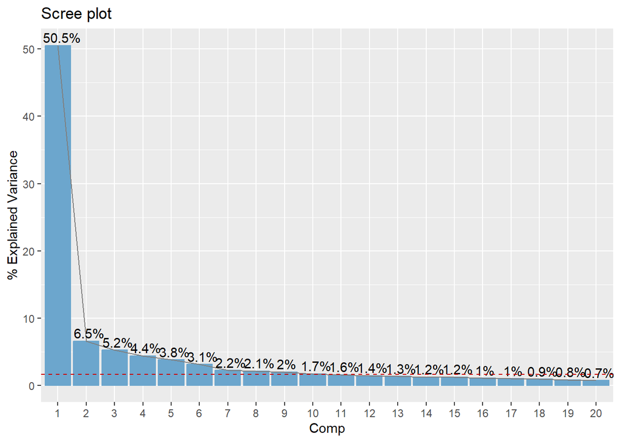

```r
metabolites_pca <- pca(
  metabolites_X,
  ncomp   = NULL,
  algo    = "nipals",
  scaling = "standard"
)

pcaPlot(metabolites_pca, type = "scree")
```

### 6.2.2 Score plots — coloreando por covariables de interés

#### Grupo (caso/control)

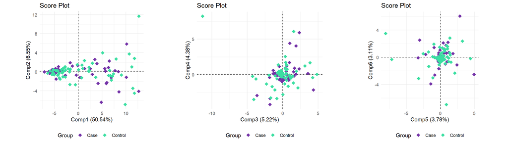

```r
p1 <- pcaPlot(metabolites_pca, type = "scores", comp = 1:2,
              colBy = data.frame(Group = metabolites_meta$group),
              labels = FALSE, ellipses = FALSE)
p2 <- pcaPlot(metabolites_pca, type = "scores", comp = 3:4,
              colBy = data.frame(Group = metabolites_meta$group),
              labels = FALSE, ellipses = FALSE)
p3 <- pcaPlot(metabolites_pca, type = "scores", comp = 5:6,
              colBy = data.frame(Group = metabolites_meta$group),
              labels = FALSE, ellipses = FALSE)

grid.arrange(p1, p2, p3, nrow = 1)
```

#### Tiempo relativo al diagnóstico

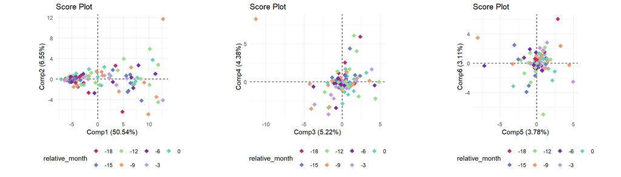

```r
metabolites_time <- factor(metabolites_meta$relative_month,
                           levels = c(-18, -15, -12, -9, -6, -3, 0))

p1 <- pcaPlot(metabolites_pca, type = "scores", comp = 1:2,
              colBy = data.frame(relative_month = metabolites_time),
              labels = FALSE, ellipses = FALSE)
p2 <- pcaPlot(metabolites_pca, type = "scores", comp = 3:4,
              colBy = data.frame(relative_month = metabolites_time),
              labels = FALSE, ellipses = FALSE)
p3 <- pcaPlot(metabolites_pca, type = "scores", comp = 5:6,
              colBy = data.frame(relative_month = metabolites_time),
              labels = FALSE, ellipses = FALSE)

grid.arrange(p1, p2, p3, nrow = 1)
```

#### País

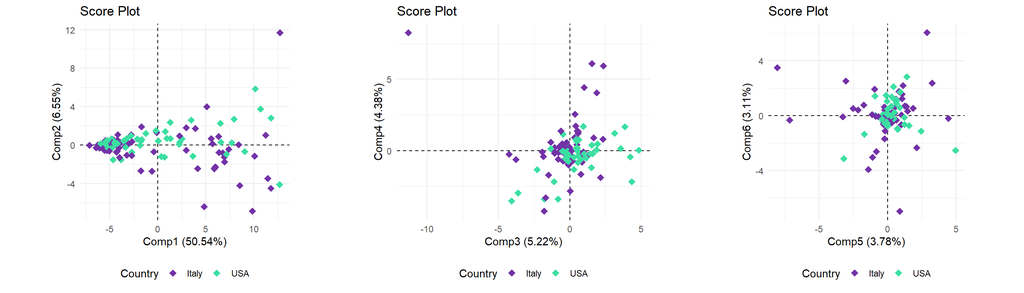

```r
p1 <- pcaPlot(metabolites_pca, type = "scores", comp = 1:2,
              colBy = data.frame(Country = metabolites_meta$Country),
              labels = FALSE, ellipses = FALSE)
p2 <- pcaPlot(metabolites_pca, type = "scores", comp = 3:4,
              colBy = data.frame(Country = metabolites_meta$Country),
              labels = FALSE, ellipses = FALSE)
p3 <- pcaPlot(metabolites_pca, type = "scores", comp = 5:6,
              colBy = data.frame(Country = metabolites_meta$Country),
              labels = FALSE, ellipses = FALSE)

grid.arrange(p1, p2, p3, nrow = 1)
```

#### Sexo

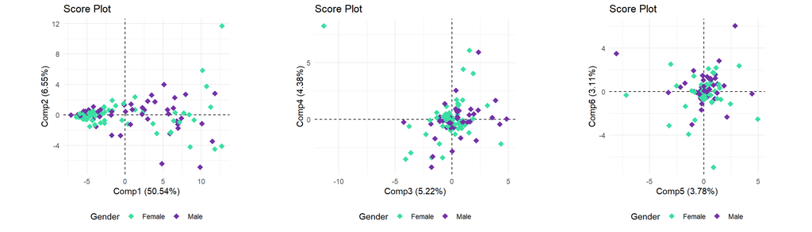

```r
p1 <- pcaPlot(metabolites_pca, type = "scores", comp = 1:2,
              colBy = data.frame(Gender = metabolites_meta$Gender),
              labels = FALSE, ellipses = FALSE)
p2 <- pcaPlot(metabolites_pca, type = "scores", comp = 3:4,
              colBy = data.frame(Gender = metabolites_meta$Gender),
              labels = FALSE, ellipses = FALSE)
p3 <- pcaPlot(metabolites_pca, type = "scores", comp = 5:6,
              colBy = data.frame(Gender = metabolites_meta$Gender),
              labels = FALSE, ellipses = FALSE)

grid.arrange(p1, p2, p3, ncol = 3)
```

#### Tipo de parto

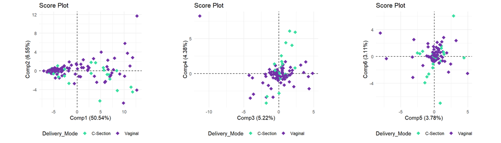

```r
p1 <- pcaPlot(metabolites_pca, type = "scores", comp = 1:2,
              colBy = data.frame(Delivery_Mode = metabolites_meta$Delivery_Mode),
              labels = FALSE, ellipses = FALSE)
p2 <- pcaPlot(metabolites_pca, type = "scores", comp = 3:4,
              colBy = data.frame(Delivery_Mode = metabolites_meta$Delivery_Mode),
              labels = FALSE, ellipses = FALSE)
p3 <- pcaPlot(metabolites_pca, type = "scores", comp = 5:6,
              colBy = data.frame(Delivery_Mode = metabolites_meta$Delivery_Mode),
              labels = FALSE, ellipses = FALSE)

grid.arrange(p1, p2, p3, ncol = 3)
```

#### Riesgo genético (HLA)

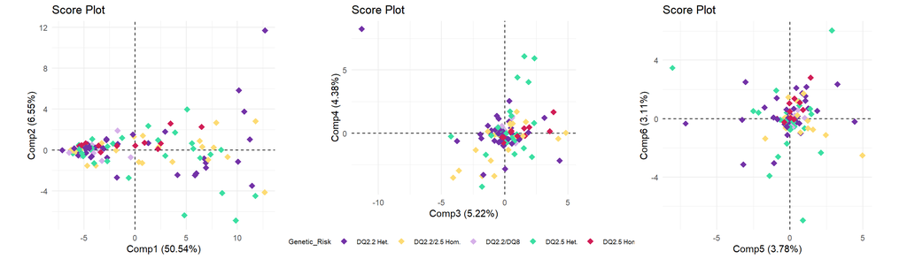

```r
genetic_risk_short <- metabolites_meta$Genetic_Risk %>%
  str_replace_all("Homozygous", "Hom.") %>%
  str_replace_all("Heterozygous", "Het.")

p1 <- pcaPlot(metabolites_pca, type = "scores", comp = 1:2,
              colBy = data.frame(Genetic_Risk = genetic_risk_short),
              labels = FALSE, ellipses = FALSE) +
  theme(legend.position = "none")

p2 <- pcaPlot(metabolites_pca, type = "scores", comp = 3:4,
              colBy = data.frame(Genetic_Risk = genetic_risk_short),
              labels = FALSE, ellipses = FALSE) +
  theme(legend.position = "bottom",
        legend.text  = element_text(size = 7),
        legend.title = element_text(size = 8))

p3 <- pcaPlot(metabolites_pca, type = "scores", comp = 5:6,
              colBy = data.frame(Genetic_Risk = genetic_risk_short),
              labels = FALSE, ellipses = FALSE) +
  theme(legend.position = "none")

grid.arrange(p1, p2, p3, ncol = 3)
```

### 6.2.3 Loadings — correlation plots y top variables

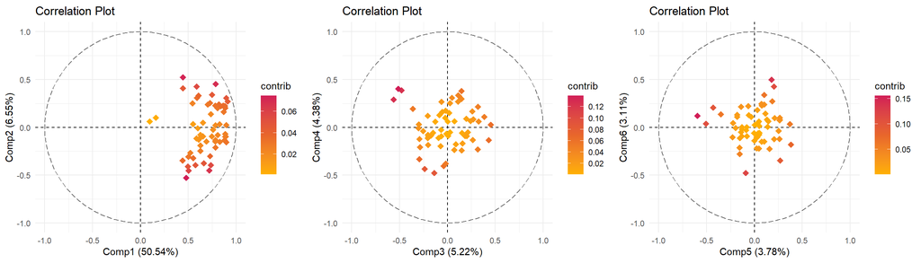

```r
l1 <- pcaPlot(metabolites_pca, type = "corr", comp = 1:2,
              colBy = "contrib", shape = "point",
              labels = FALSE, repel = TRUE, col = "hot")
l2 <- pcaPlot(metabolites_pca, type = "corr", comp = 3:4,
              colBy = "contrib", shape = "point",
              labels = FALSE, repel = TRUE, col = "hot")
l3 <- pcaPlot(metabolites_pca, type = "corr", comp = 5:6,
              colBy = "contrib", shape = "point",
              labels = FALSE, repel = TRUE, col = "hot")

grid.arrange(l1, l2, l3, ncol = 3)
```

**Top 10 metabolitos — PC1 y PC2**

```r
metabolites_top_PC12 <- tibble(
  variable    = rownames(metabolites_pca$loadings),
  loading_PC1 = metabolites_pca$loadings[, 1],
  loading_PC2 = metabolites_pca$loadings[, 2]
) %>%
  mutate(contribution_PC12 = loading_PC1^2 + loading_PC2^2) %>%
  arrange(desc(contribution_PC12)) %>%
  slice_head(n = 10)

kable(metabolites_top_PC12)
```

| variable | loading_PC1 | loading_PC2 | contribution_PC12 |
| --- | --- | --- | --- |
| Allose | 0.0848245 | -0.2599994 | 0.0747949 |
| Xylose | 0.0786166 | 0.2576638 | 0.0725712 |
| X2.Keto.3.methylvaleric.acid | 0.1394731 | 0.2230835 | 0.0692190 |
| Ribonic.acid | 0.1276883 | -0.2228837 | 0.0659815 |
| Glucose | 0.0891696 | -0.2236849 | 0.0579861 |
| Arabinopyranose | 0.1305904 | -0.1944486 | 0.0548641 |
| Arabinose..peak.1. | 0.1040455 | 0.2098488 | 0.0548620 |
| N.Acetyl.D.galactosamine | 0.0880573 | -0.2013238 | 0.0482853 |
| Butanoic.acid | 0.1589185 | 0.1513467 | 0.0481609 |
| Tagatose | 0.1019162 | -0.1940119 | 0.0480275 |

**Top 10 metabolitos — PC3 y PC4**

```r
metabolites_top_PC34 <- tibble(
  variable    = rownames(metabolites_pca$loadings),
  loading_PC3 = metabolites_pca$loadings[, 3],
  loading_PC4 = metabolites_pca$loadings[, 4]
) %>%
  mutate(contribution_PC34 = loading_PC3^2 + loading_PC4^2) %>%
  arrange(desc(contribution_PC34)) %>%
  slice_head(n = 10)

kable(metabolites_top_PC34)
```

| variable | loading_PC3 | loading_PC4 | contribution_PC34 |
| --- | --- | --- | --- |
| Xylose | -0.2838154 | 0.2426685 | 0.1394392 |
| xi.2.Ethyl.1.hexanol | -0.3103514 | 0.1751230 | 0.1269861 |
| Arabinose..peak.1. | -0.2648211 | 0.2335847 | 0.1246921 |
| X2.Hydroxyisocaproic.acid | -0.0760909 | -0.2874805 | 0.0884348 |
| X2.Deoxy.D.ribose | -0.1311314 | -0.2626127 | 0.0861609 |
| Butanedioic.acid | -0.1620327 | -0.1996027 | 0.0660959 |
| Glyceric.acid | 0.2386941 | -0.0799463 | 0.0633663 |
| Ribose | 0.2502874 | 0.0158337 | 0.0628945 |
| Glycerol | -0.0212408 | -0.2433497 | 0.0596702 |
| Myristic.acid | 0.0812631 | 0.2293411 | 0.0592010 |

**Top 10 metabolitos — PC5 y PC6**

```r
metabolites_top_PC56 <- tibble(
  variable    = rownames(metabolites_pca$loadings),
  loading_PC5 = metabolites_pca$loadings[, 5],
  loading_PC6 = metabolites_pca$loadings[, 6]
) %>%
  mutate(contribution_PC56 = loading_PC5^2 + loading_PC6^2) %>%
  arrange(desc(contribution_PC56)) %>%
  slice_head(n = 10)

kable(metabolites_top_PC56)
```

| variable | loading_PC5 | loading_PC6 | contribution_PC56 |
| --- | --- | --- | --- |
| X3.Hydroxyphenylacetic.acid | -0.3856637 | 0.0867043 | 0.1562541 |
| Allose | 0.1167252 | 0.3549722 | 0.1396300 |
| X1.Deoxypentitol | -0.0591743 | -0.3412111 | 0.1199266 |
| Glucose | 0.1322500 | 0.3054699 | 0.1108020 |
| Benzoic.acid | -0.3280501 | 0.0259763 | 0.1082917 |
| Propanal | -0.2796613 | 0.1485603 | 0.1002806 |
| N.Acetyl.D.galactosamine | 0.1739215 | -0.2476229 | 0.0915658 |
| Arabinonic.acid | 0.2476113 | -0.1294730 | 0.0780746 |
| Glycine | 0.0666323 | 0.2424514 | 0.0632226 |
| Serine | -0.2270226 | 0.0980532 | 0.0611537 |

Fijamos el número de componentes antes de estudiar los anómalos para evitar problemas con los gráficos.

```r
metabolites_pca <- pca(
  metabolites_X,
  ncomp   = 6,
  algo    = "nipals",
  scaling = "standard"
)
```

### 6.2.4 Detección de muestras anómalas

```r
par(mfrow = c(1, 2))

metabolites_out_RSS <- pcaOutliers(metabolites_pca, ncomp = metabolites_pca$ncomp,method = "RSS", conf = 0.95)

metabolites_out_T2  <- pcaOutliers(metabolites_pca, ncomp = metabolites_pca$ncomp,method = "T2",  conf = 0.95)
```

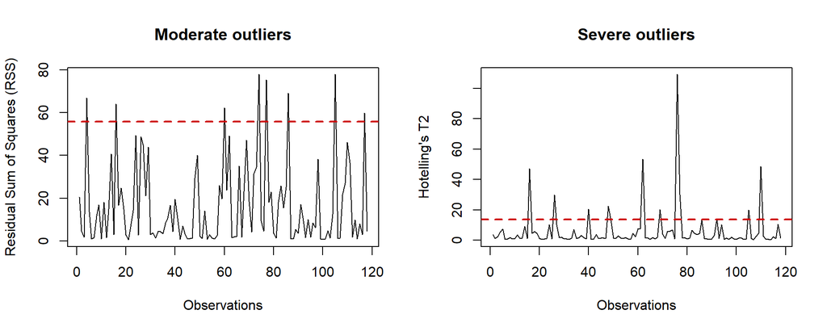

```r
par(mfrow = c(1, 1))
```

```r
metabolites_moderate <- sort(
  metabolites_out_RSS$RSS[metabolites_out_RSS$ModerateOutliers],
  decreasing = TRUE
)

metabolites_severe <- sort(
  metabolites_out_T2$T2[metabolites_out_T2$SevereOutliers],
  decreasing = TRUE
)

cat("Anómalos moderados (RSS) al 95 :\n"); print(metabolites_moderate)
```

```
## Anómalos moderados (RSS) al 95 :
```

```
##  Control_2_9_month Control_7_30_month Control_3_18_month  Control_4_9_month
##           77.82612           77.80066           75.18424           69.10927
##     Case_1_6_month     Case_2_6_month Control_1_18_month Control_9_27_month
##           66.78196           63.96785           62.27382           59.70010
```

```r
cat("\nAnómalos severos (T²) al 95 :\n");   print(metabolites_severe)
```

```
##
## Anómalos severos (T²) al 95 :
```

```
## Control_3_15_month  Control_1_9_month  Control_8_6_month     Case_2_6_month
##          109.31465           53.36273           48.52275           47.23253
## Control_3_18_month    Case_4_15_month     Case_8_3_month    Case_7_18_month
##           30.11276           29.93972           22.58050           20.37880
## Control_2_15_month Control_7_30_month Control_6_12_month
##           20.15410           19.83249           14.25926
```

```r
par(mfrow = c(1, 2))

metabolites_out_RSS_99 <- pcaOutliers(metabolites_pca, ncomp = metabolites_pca$ncomp,method = "RSS", conf = 0.99)

metabolites_out_T2_99  <- pcaOutliers(metabolites_pca, ncomp = metabolites_pca$ncomp,method = "T2",  conf = 0.99)
```

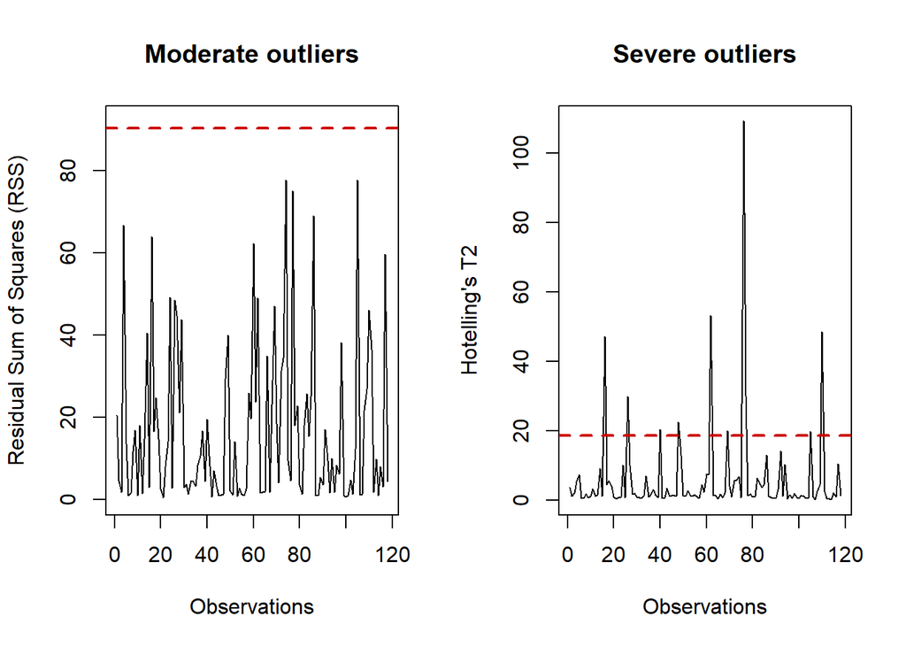

```r
par(mfrow = c(1, 1))
```

```r
metabolites_moderate_99 <- sort(metabolites_out_RSS_99$RSS[metabolites_out_RSS_99$ModerateOutliers],
                    decreasing = TRUE)
metabolites_severe_99   <- sort(metabolites_out_T2_99$T2[metabolites_out_T2_99$SevereOutliers],
                    decreasing = TRUE)

cat("Moderados (RSS) al 99 :\n"); print(metabolites_moderate_99)
```

```
## Moderados (RSS) al 99 :
```

```
## named numeric(0)
```

```r
cat("Severos   (T²) al 99 :\n");  print(metabolites_severe_99)
```

```
## Severos   (T²) al 99 :
```

```
## Control_3_15_month  Control_1_9_month  Control_8_6_month     Case_2_6_month
##          109.31465           53.36273           48.52275           47.23253
## Control_3_18_month    Case_4_15_month     Case_8_3_month    Case_7_18_month
##           30.11276           29.93972           22.58050           20.37880
## Control_2_15_month Control_7_30_month
##           20.15410           19.83249
```

```r
metabolites_contrib_T2_99 <- outlierContrib(metabolites_pca, metabolites_out_T2_99)
```

```
## There are 10 severe outliers in the data provided.
```

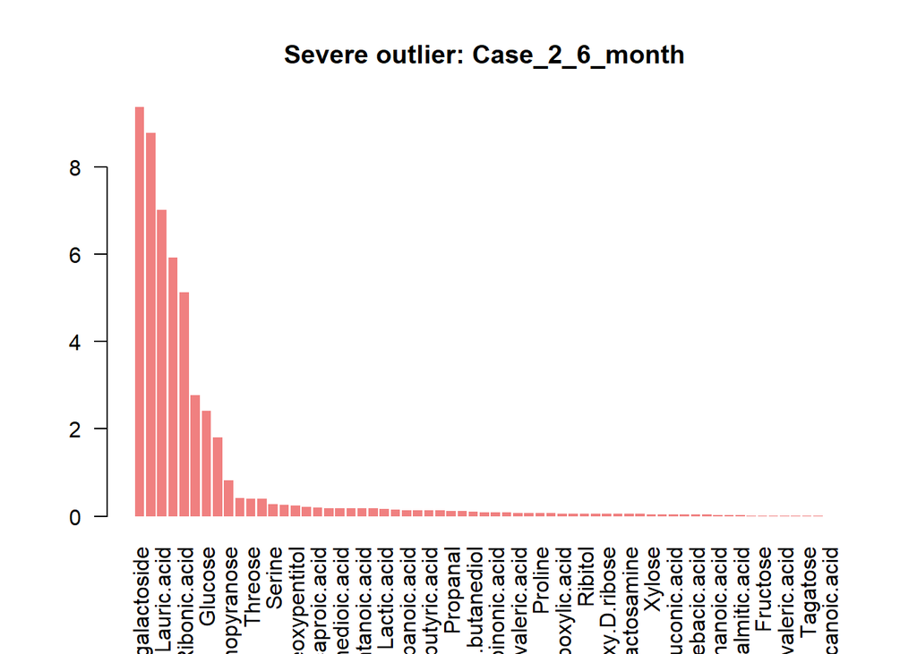

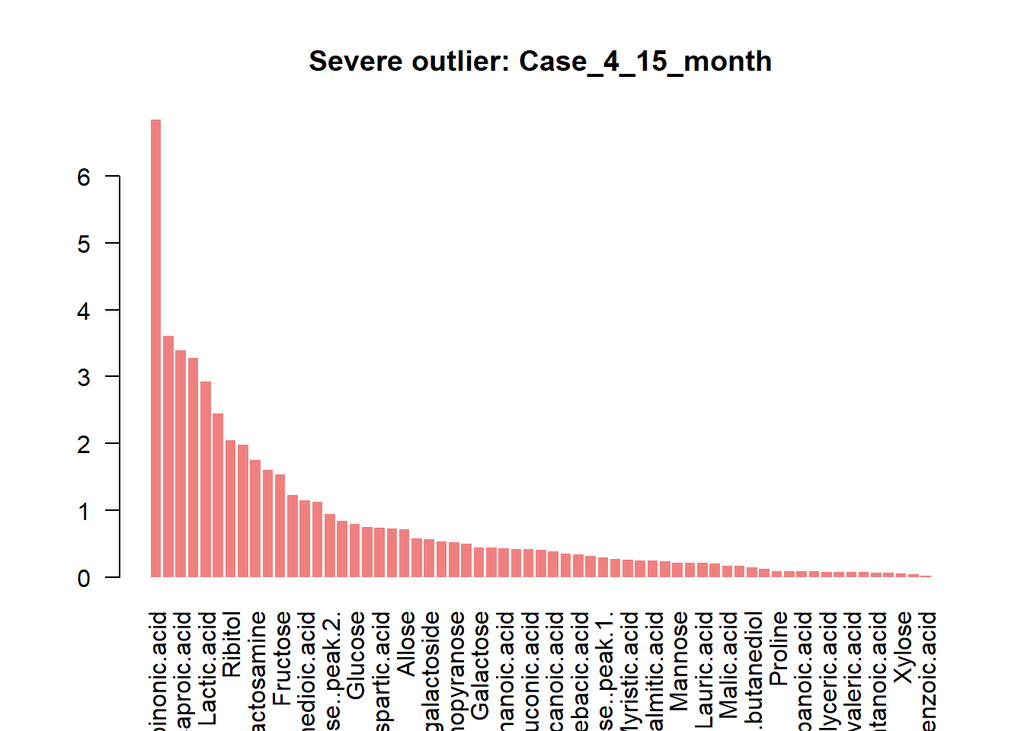

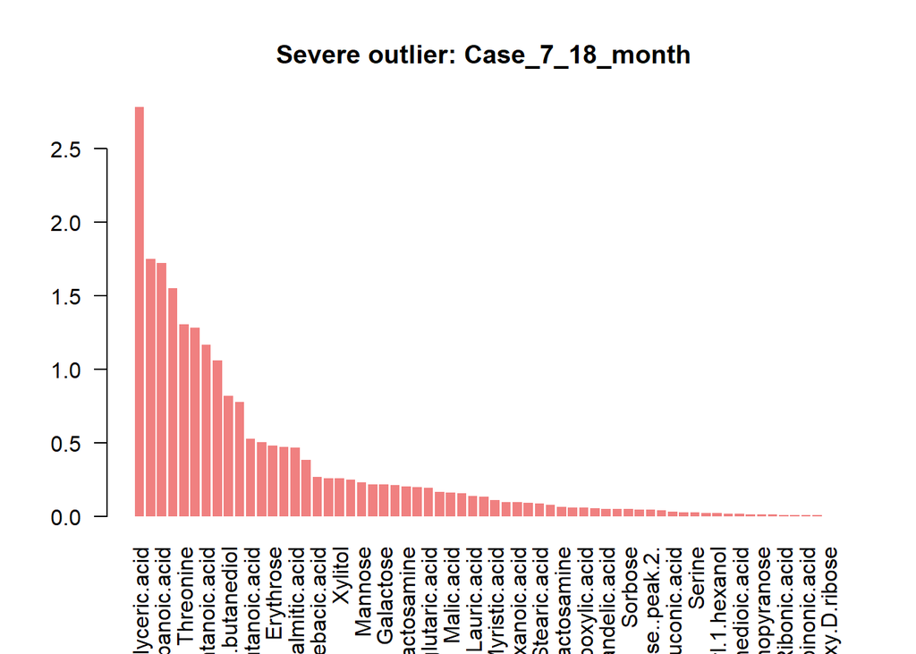

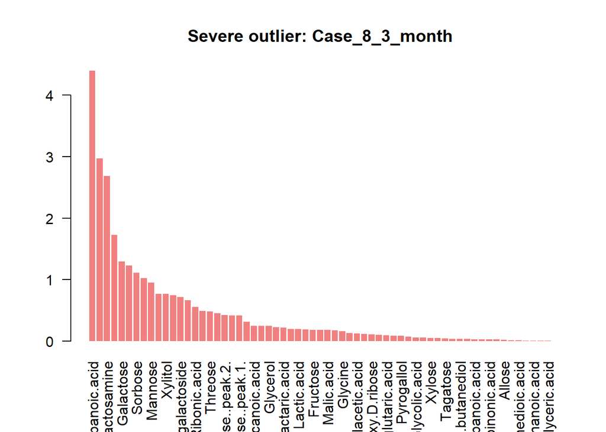

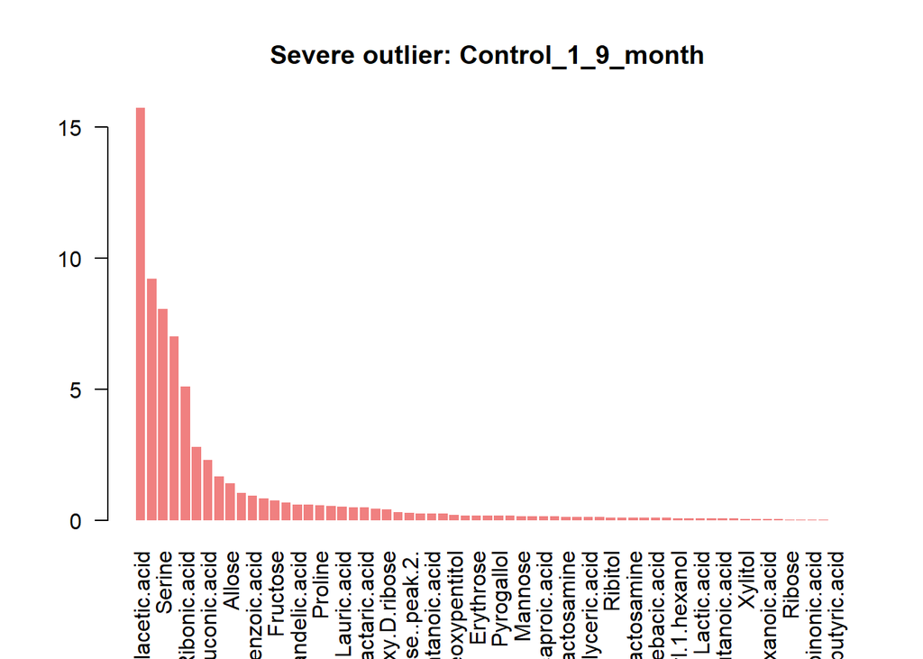

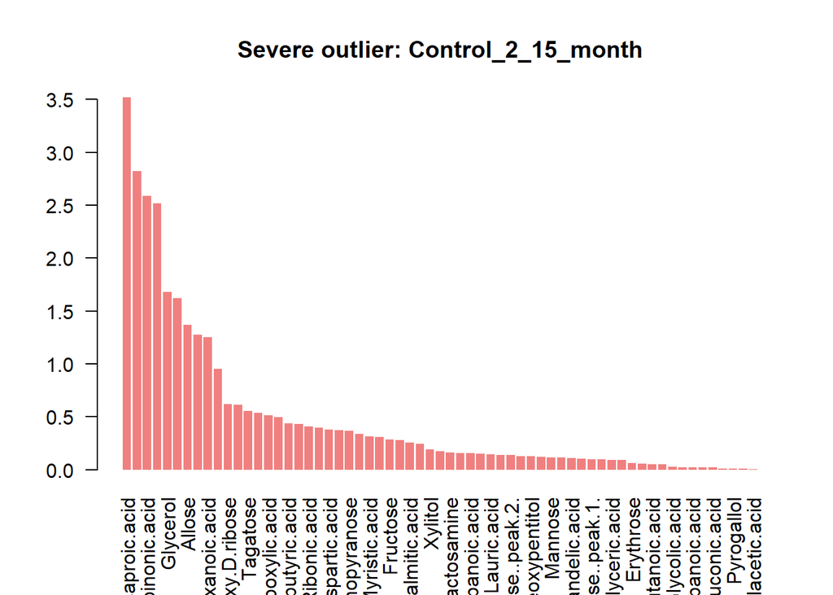

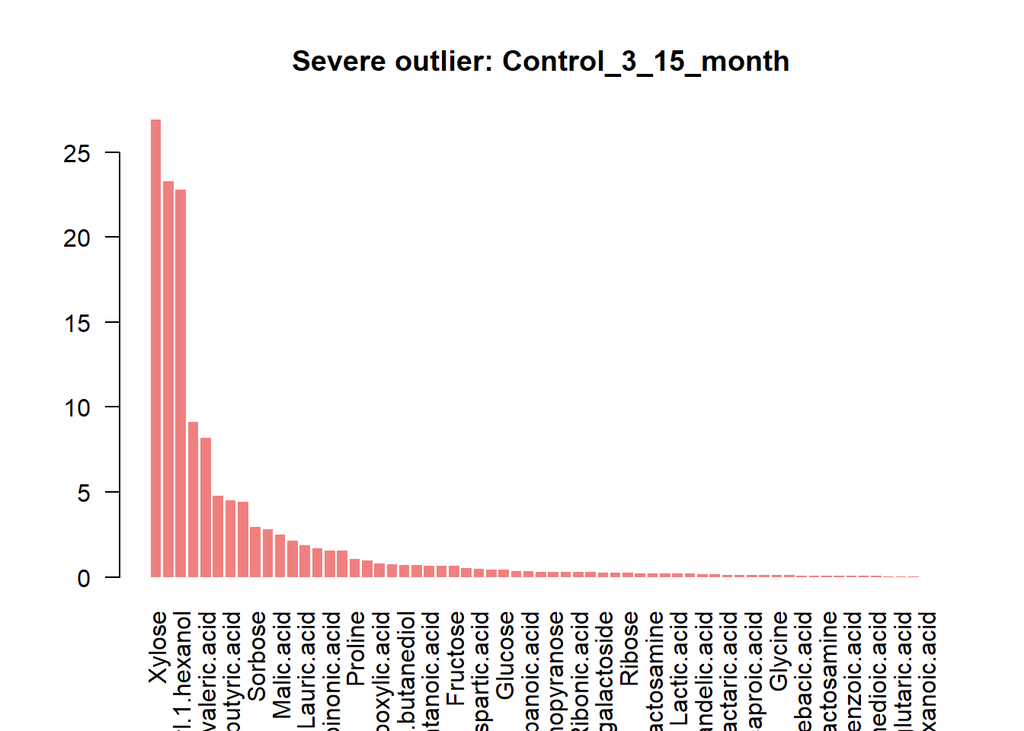

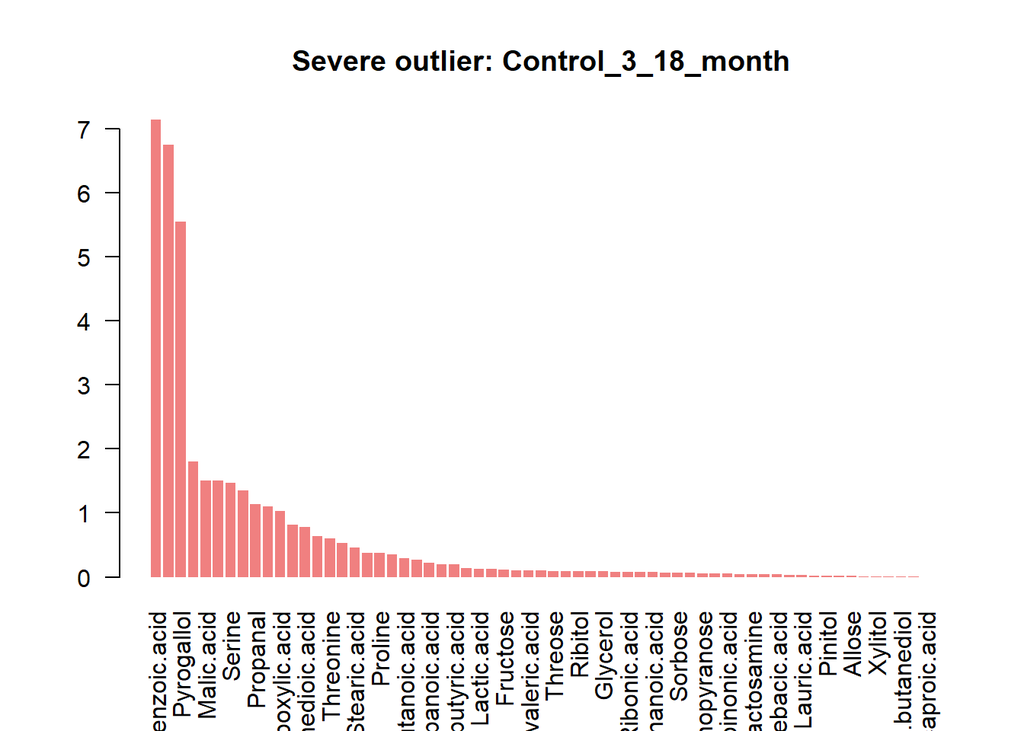

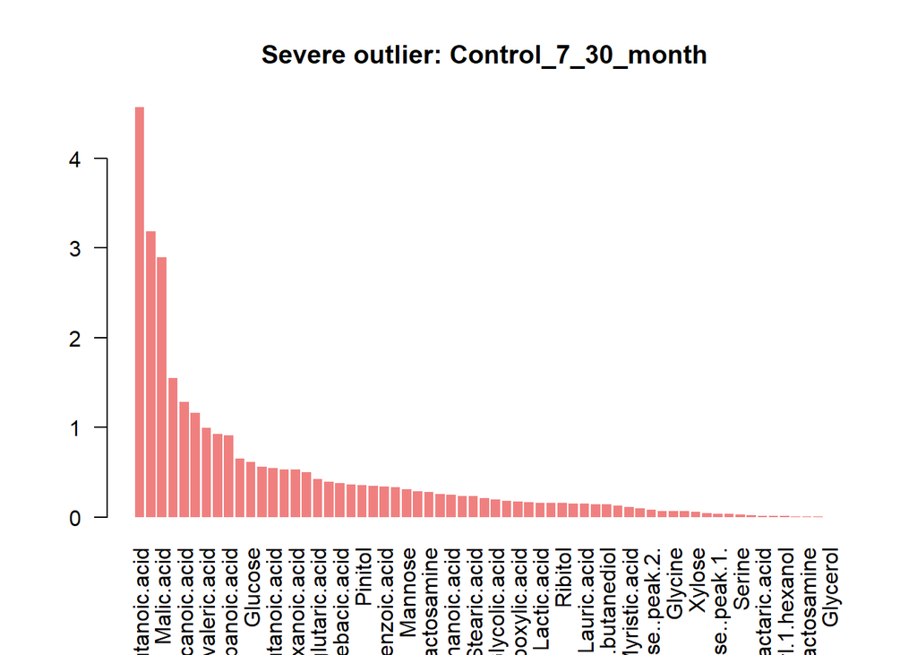

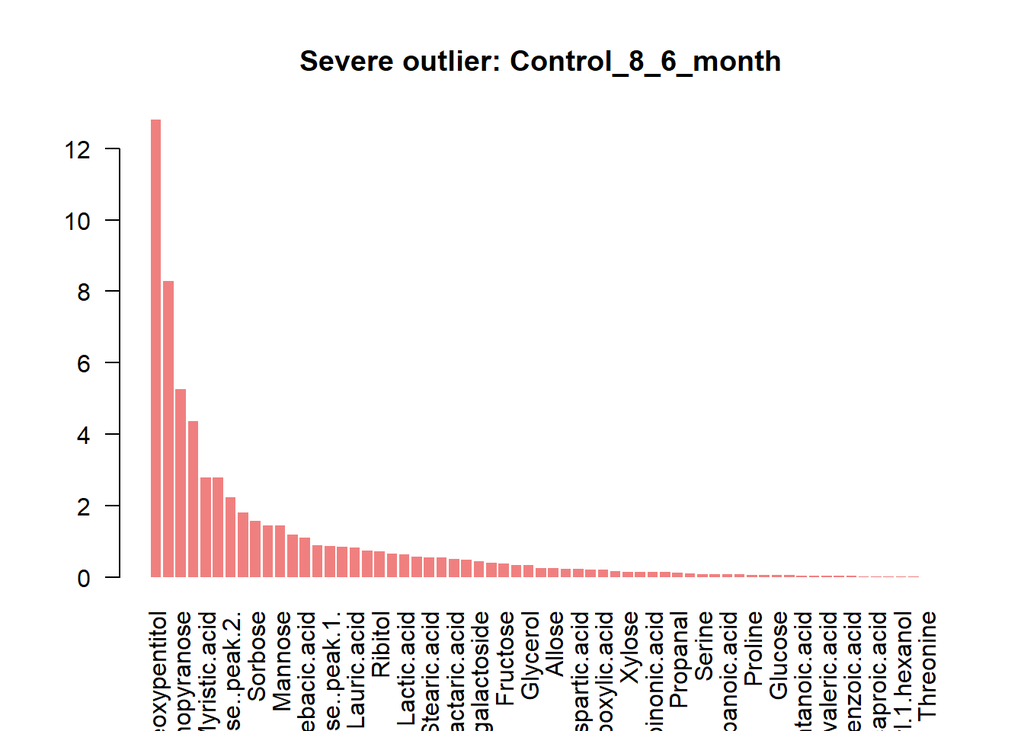

```
## There are no moderate outliers in the data or they were not computed.
```

```r
top10_severe_metabolites <- get_top_contrib_list(metabolites_contrib_T2_99$contribT2)

top10_severe_metabolites
```

```
## [[1]]
## # A tibble: 10 × 3
##    sample_id      pathway            contribution
##    <chr>          <chr>                     <dbl>
##  1 Case_2_6_month Methyl.galactoside        9.37
##  2 Case_2_6_month Allose                    8.78
##  3 Case_2_6_month Lauric.acid               7.01
##  4 Case_2_6_month Myristic.acid             5.92
##  5 Case_2_6_month Ribonic.acid              5.13
##  6 Case_2_6_month Arabinose..peak.2.        2.77
##  7 Case_2_6_month Glucose                   2.41
##  8 Case_2_6_month Glycine                   1.80
##  9 Case_2_6_month Arabinopyranose           0.826
## 10 Case_2_6_month Pinitol                   0.412
##
## [[2]]
## # A tibble: 10 × 3
##    sample_id       pathway                         contribution
##    <chr>           <chr>                                  <dbl>
##  1 Case_4_15_month Arabinonic.acid                         6.84
##  2 Case_4_15_month X2.Hydroxy.3.methylbutyric.acid         3.61
##  3 Case_4_15_month X2.Hydroxyisocaproic.acid               3.39
##  4 Case_4_15_month Galactaric.acid                         3.28
##  5 Case_4_15_month Lactic.acid                             2.93
##  6 Case_4_15_month Threose                                 2.45
##  7 Case_4_15_month Ribitol                                 2.04
##  8 Case_4_15_month Hexanoic.acid                           1.98
##  9 Case_4_15_month N.Acetyl.D.galactosamine                1.75
## 10 Case_4_15_month X1.Deoxypentitol                        1.60
##
## [[3]]
## # A tibble: 10 × 3
##    sample_id       pathway                      contribution
##    <chr>           <chr>                               <dbl>
##  1 Case_7_18_month Glyceric.acid                       2.78
##  2 Case_7_18_month Butanoic.acid                       1.75
##  3 Case_7_18_month Benzenepropanoic.acid               1.72
##  4 Case_7_18_month Ribose                              1.55
##  5 Case_7_18_month Threonine                           1.31
##  6 Case_7_18_month alpha.Ketoisovaleric.acid           1.28
```

[output cut: 94 more lines]

```
##
## [[10]]
## # A tibble: 10 × 3
##    sample_id         pathway                           contribution
##    <chr>             <chr>                                    <dbl>
##  1 Control_8_6_month X1.Deoxypentitol                         12.8
##  2 Control_8_6_month N.Acetyl.D.galactosamine                  8.29
##  3 Control_8_6_month Arabinopyranose                           5.26
##  4 Control_8_6_month Galactose                                 4.36
##  5 Control_8_6_month Myristic.acid                             2.79
##  6 Control_8_6_month X3.Hydroxy.3.phenylpropanoic.acid         2.79
##  7 Control_8_6_month Arabinose..peak.2.                        2.23
##  8 Control_8_6_month Pinitol                                   1.80
##  9 Control_8_6_month Sorbose                                   1.56
## 10 Control_8_6_month Xylitol                                   1.44
```